# Figures + Tables

[figure not shown]

```r
GSE125605 %>% filter(Class == "EOPE") %>%
  ggplot(aes(x=Pred_Class_Best, y=GA_RPC)) +
  geom_boxplot(aes(color=Pred_Class_Best, fill=Pred_Class_Best), alpha=0.6, width=0.5) +
  geom_jitter(aes(color=Pred_Class_Best)) +
  scale_color_manual(name = "Predicted Class", values=c("#E69F00", "#999999")) +
  scale_fill_manual(name = "Predicted Class", values=c("#E69F00", "#999999")) +
  theme_minimal() +
  xlab("Predicted Class at 55% Threshold") +
  ylab("Gestational Age") +
  stat_compare_means(label="p.format") +
  scale_x_discrete(labels=c("EOPE" = "EOPE (n=15)", "Non-PE Preterm" = "Non-PE Preterm (n=7)"))
```

What if I compare the gestational age not only at GSE125605 but at all the validation group classifications vs. misclassifications.

```r
tabyl(meta %>% filter(Group == "Validation" & Class == "EOPE"), Class, Pred_Class_Best)
```

```
##  Class EOPE Non-PE Preterm
##   EOPE   23             15
```

```r
range(as.data.frame(meta %>% filter(Group == "Validation" & Class == "EOPE"))$GA_RPC)
```

```
## [1] 25.88587 39.62145
```

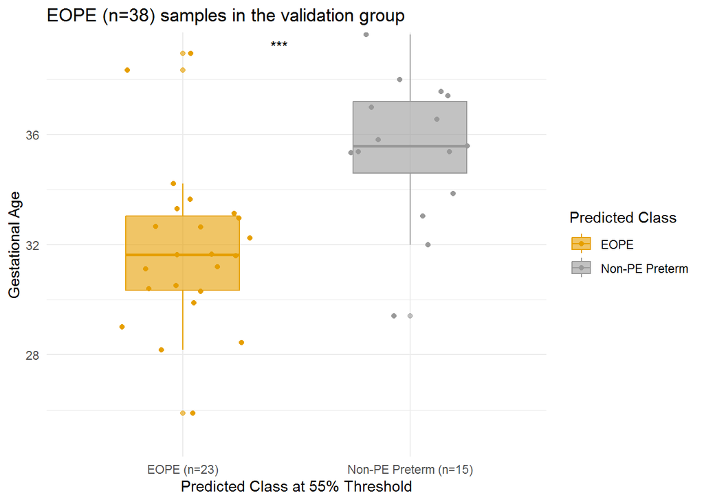

```r
jitter <- position_jitter(width = 0.3)

meta %>%
  filter(Group == "Validation" & Class == "EOPE") %>%
  mutate(Ancestry = case_when(Predicted_ethnicity_nothresh == "African" ~ "African",
                              Predicted_ethnicity_nothresh == "Asian" ~ "Asian",
                              Predicted_ethnicity_nothresh == "Caucasian" ~ "European")) %>%
  ggplot(aes(x=Pred_Class_Best, y=GA_RPC)) +
  geom_boxplot(aes(color=Pred_Class_Best, fill=Pred_Class_Best), alpha=0.6, width=0.5) +
  geom_point(aes(color=Pred_Class_Best), position = jitter) +
  scale_color_manual(name = "Predicted Class", values=c("#E69F00", "#999999")) +
  scale_fill_manual(name = "Predicted Class", values=c("#E69F00", "#999999")) +
  theme_minimal() +
  xlab("Predicted Class at 55% Threshold") +
  ylab("Gestational Age") +
  stat_compare_means(label="p.signif", label.x=1.4, label.y=39) +
  scale_x_discrete(labels=c("EOPE" = "EOPE (n=23)", "Non-PE Preterm" = "Non-PE Preterm (n=15)")) +
  coord_cartesian(ylim=c(25, 39)) +
  ggtitle("EOPE (n=38) samples in the validation group")
```

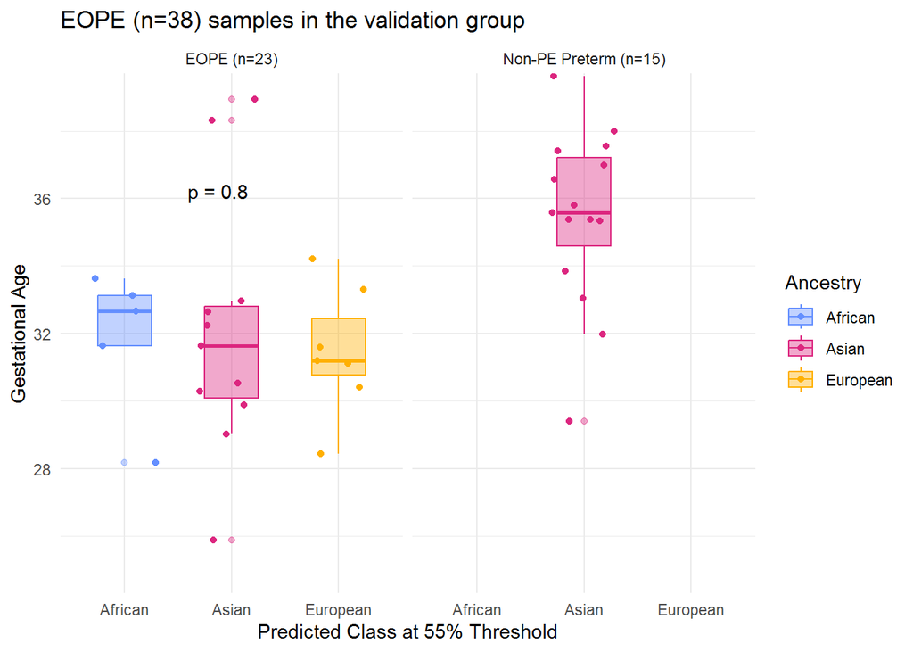

```r
ggsave(file="Figure3C.png",
       width=5, height=5,
       path = here::here("Output", "2022_Manuscript"),
       bg = "transparent",
       dpi=500)

meta %>%
  filter(Group == "Validation" & Class == "EOPE") %>%
  mutate(Ancestry = case_when(Predicted_ethnicity_nothresh == "African" ~ "African",
                              Predicted_ethnicity_nothresh == "Asian" ~ "Asian",
                              Predicted_ethnicity_nothresh == "Caucasian" ~ "European")) %>%
  mutate(Pred_Class_Best = case_when(Pred_Class_Best == "EOPE" ~ "EOPE (n=23)",
                                     Pred_Class_Best == "Non-PE Preterm" ~ "Non-PE Preterm (n=15)")) %>%
  ggplot(aes(x=Ancestry, y=GA_RPC)) +
  geom_boxplot(aes(color=Ancestry, fill=Ancestry), alpha=0.4, width=0.5) +
  geom_point(aes(color=Ancestry), position = jitter) +
  scale_color_manual(name = "Ancestry", values=c("#648FFF", "#DC267F", "#FFB000")) +
  scale_fill_manual(name = "Ancestry", values=c("#648FFF", "#DC267F", "#FFB000")) +
  theme_minimal() +
  facet_wrap(~Pred_Class_Best) +
  xlab("Predicted Class at 55% Threshold") +
  ylab("Gestational Age") +
  coord_cartesian(ylim=c(25, 39)) +
  stat_compare_means(label="p.format", label.x=1.7, label.y=36) +
  ggtitle("EOPE (n=38) samples in the validation group")
```

```r
ggsave(file="Figure3D.png",
       width=5, height=5,
       path = here::here("Output", "2022_Manuscript"),
       bg = "transparent",
       dpi=500)
```

# Characterization of LOPE and FGR cases in the exploratory cohort, by their predicted outcome (Table 3 + in-text information)

## In-text annotations

```r
range(as.data.frame(meta %>% filter(Group == "Validation") %>% filter(Class == "EOPE" & Pred_Class_Best == "EOPE"))$EOPE)
```

```
## [1] 0.5579658 0.8187693
```

```r
mean(as.data.frame(meta %>% filter(Group == "Validation") %>% filter(Class == "EOPE" & Pred_Class_Best == "EOPE"))$EOPE)
```

```
## [1] 0.6902103
```

```r
mean(as.data.frame(meta %>% filter(Group == "Validation") %>% filter(Class == "EOPE" & Pred_Class_Best == "EOPE"))$GA_RPC)
```

```
## [1] 31.81815
```

```r
mean(as.data.frame(meta %>% filter(Group == "Validation") %>% filter(Class == "EOPE" & Pred_Class_Best == "Non-PE Preterm"))$GA_RPC)
```

```
## [1] 35.45558
```

```r
range(as.data.frame(meta %>% filter(Group == "Validation") %>% filter(Class == "Non-PE Preterm" & Pred_Class_Best == "Non-PE Preterm"))$EOPE)
```

```
## [1] 0.2794939 0.5328715
```

```r
mean(as.data.frame(meta %>% filter(Group == "Validation") %>% filter(Class == "Non-PE Preterm" & Pred_Class_Best == "Non-PE Preterm"))$EOPE)
```

```
## [1] 0.4119449
```

```r
meta %>% filter(Group == "Validation") %>% filter(Class == "Non-PE Preterm" & Pred_Class_Best == "EOPE")
```

```
##   Sample_ID Subject_ID GEO_Dataset    Sex Condition    IUGR Preterm Term   PE
## 1     TO-35       <NA>   GSE203396 Female      <NA> Unknown    <NA> <NA> <NA>
##      GA   GA_RPC Ethnicity Maternal_Age Chip  Row Column
## 1 36.42 35.91371      <NA>           NA   NA <NA>   <NA>
##   Predicted_ethnicity_nothresh Predicted_ethnicity Prob_African  Prob_Asian
## 1                    Caucasian                <NA>  0.003133612 0.009577267
##   Prob_Caucasian Highest_Prob          Class        X         Y DNAme_Sex
## 1      0.9872891           NA Non-PE Preterm 1.059613 0.1600528        XX
##   FAIL_DNAme_Sex      EOPE Non-PE Preterm Pred_Class Trophoblasts   Stromal
## 1          FALSE 0.6678493      0.3321507       EOPE    0.1209836 0.1110147
##   Hofbauer Endothelial        nRBC Syncytiotrophoblast      Group Pred_Class_60
## 1        0   0.1100656 0.006943031            0.606559 Validation          EOPE
##   Pred_Class_Best
## 1            EOPE
```

```r
dim(meta %>% filter(Group == "Exploratory"))
```

```
## [1] 328  39
```

```r
tabyl(meta %>% filter(Group == "Exploratory"), Class)
```

```
##           Class   n     percent
##           CPM16  10 0.030487805
##            EOPE   2 0.006097561
##             FGR  46 0.140243902
##          LatePE  86 0.262195122
##  Non-PE Preterm   3 0.009146341
##     Non-PE Term 181 0.551829268
```

```r
round(range(as.data.frame(meta %>% filter(Group == "Exploratory") %>% filter(Class %in% c("Non-PE Preterm", "Non-PE Term") & Pred_Class_Best == "Non-PE Preterm"))$EOPE),2)
```

```
## [1] 0.08 0.53
```

```r
round(median(as.data.frame(meta %>% filter(Group == "Exploratory") %>% filter(Class %in% c("Non-PE Preterm", "Non-PE Term") & Pred_Class_Best == "Non-PE Preterm"))$EOPE),2)
```

```
## [1] 0.31
```

```r
dim(as.data.frame(meta %>% filter(Group == "Exploratory") %>% filter(Class %in% c("Non-PE Preterm", "Non-PE Term") & Pred_Class_Best == "Non-PE Preterm")))
```

```
## [1] 169  39
```

```r
meta %>% filter(Group == "Exploratory") %>% filter(Class == "EOPE")
```

```
##    Sample_ID Subject_ID GEO_Dataset    Sex Condition    IUGR Preterm Term  PE
## 1 GSM1944939       <NA>    GSE75196   Male        PE Unknown     Yes   No Yes
## 2 GSM3423399       PL91   GSE120981 Female        PE     Yes     Yes   No Yes
##   GA   GA_RPC Ethnicity Maternal_Age       Chip  Row Column
## 1 32 32.57168      <NA>           NA 9376561054  R02    C01
## 2 NA 32.99727      <NA>           NA         NA <NA>   <NA>
##   Predicted_ethnicity_nothresh Predicted_ethnicity Prob_African  Prob_Asian
## 1                    Caucasian           Caucasian  0.004322243 0.001999446
## 2                    Caucasian           Caucasian  0.021482799 0.030035894
##   Prob_Caucasian Highest_Prob Class         X         Y DNAme_Sex
## 1      0.9936783    0.9936783  EOPE 0.7396998 0.8115636        XY
## 2      0.9484813    0.9484813  EOPE 1.0231145 0.1308639        XX
##   FAIL_DNAme_Sex      EOPE Non-PE Preterm Pred_Class Trophoblasts    Stromal
## 1          FALSE 0.7255915      0.2744085       EOPE    0.1866164 0.01950722
## 2          FALSE 0.8608640      0.1391360       EOPE    0.1751688 0.03380132
##   Hofbauer Endothelial       nRBC Syncytiotrophoblast       Group Pred_Class_60
## 1        0  0.09646969 0.04235755           0.6226299 Exploratory          EOPE
## 2        0  0.09096742 0.04078767           0.6044858 Exploratory          EOPE
##   Pred_Class_Best
## 1            EOPE
## 2            EOPE
```

```r
round(mean(as.data.frame(meta %>% filter(Group == "Exploratory") %>% filter(Class == "LatePE" & Pred_Class_Best == "EOPE" & IUGR == "Yes"))$EOPE),2)
```

```
## [1] 0.69
```

```r
meta %>% filter(Group == "Exploratory") %>% filter(Class == "LatePE" & Pred_Class_Best == "Non-PE Preterm" & IUGR == "Yes")
```

```
##    Sample_ID Subject_ID GEO_Dataset  Sex Condition IUGR Preterm Term  PE    GA
## 1 GSM2589555       <NA>    GSE98224 Male        PE  Yes     Yes   No Yes 36.86
## 2 GSM3423401       PL98   GSE120981 Male        PE  Yes     Yes   No Yes    NA
##     GA_RPC Ethnicity Maternal_Age        Chip  Row Column
## 1 36.06020     Black           35 10005833037  R01    C01
## 2 35.03065      <NA>           NA          NA <NA>   <NA>
##   Predicted_ethnicity_nothresh Predicted_ethnicity Prob_African  Prob_Asian
## 1                      African             African  0.996406999 0.003124075
## 2                    Caucasian           Caucasian  0.005707752 0.008297204
##   Prob_Caucasian Highest_Prob  Class         X         Y DNAme_Sex
## 1    0.000468926     0.996407 LatePE 0.8039263 0.8497354        XY
## 2    0.985995044     0.985995 LatePE 0.6957339 0.7864499        XY
##   FAIL_DNAme_Sex      EOPE Non-PE Preterm     Pred_Class Trophoblasts   Stromal
## 1          FALSE 0.5385361      0.4614639           EOPE    0.1193887 0.1140416
## 2          FALSE 0.2778607      0.7221393 Non-PE Preterm    0.2532682 0.1119597
##     Hofbauer Endothelial       nRBC Syncytiotrophoblast       Group
## 1 0.03173527  0.09179575 0.08771019           0.5330942 Exploratory
## 2 0.03137136  0.11334299 0.02269537           0.4465536 Exploratory
##    Pred_Class_60 Pred_Class_Best
## 1 Non-PE Preterm  Non-PE Preterm
## 2 Non-PE Preterm  Non-PE Preterm
```

```r
range(mean(meta %>% filter(Condition == "CPM16") %>% filter(Pred_Class_Best == "EOPE")))
```

```
## [1] NA NA
```

## Information for table

```r
dim(meta %>% filter(Class == "LatePE")) # 86
```

```
## [1] 86 39
```

```r
dim(meta %>% filter(Class == "FGR")) # 46
```

```
## [1] 46 39
```

```r
tabyl(meta %>% filter(Class == "LatePE"), Pred_Class_Best)
```

```
##  Pred_Class_Best  n   percent
##             EOPE 24 0.2790698
##   Non-PE Preterm 62 0.7209302
```

```r
tabyl(meta %>% filter(Class == "FGR"), Pred_Class_Best)
```

```
##  Pred_Class_Best  n   percent
##             EOPE  9 0.1956522
##   Non-PE Preterm 37 0.8043478
```

```r
##### EOPE PROB #####

# late-pe as eope
round(range(as.data.frame(meta %>% filter(Class == "LatePE" & Pred_Class_Best == "EOPE"))$EOPE), 2)
```

```
## [1] 0.57 0.82
```

```r
round(mean(as.data.frame(meta %>% filter(Class == "LatePE" & Pred_Class_Best == "EOPE"))$EOPE), 2)
```

```
## [1] 0.7
```

```r
# fgr as eope
round(range(as.data.frame(meta %>% filter(Class == "FGR" & Pred_Class_Best == "EOPE"))$EOPE), 2)
```

```
## [1] 0.55 0.79
```

```r
round(mean(as.data.frame(meta %>% filter(Class == "FGR" & Pred_Class_Best == "EOPE"))$EOPE), 2)
```

```
## [1] 0.68
```

```r
# late pe as nptb
round(range(as.data.frame(meta %>% filter(Class == "LatePE" & Pred_Class_Best == "Non-PE Preterm"))$EOPE), 2)
```

```
## [1] 0.13 0.54
```

```r
round(mean(as.data.frame(meta %>% filter(Class == "LatePE" & Pred_Class_Best == "Non-PE Preterm"))$EOPE), 2)
```

```
## [1] 0.34
```

```r
# fgr as nptb
round(range(as.data.frame(meta %>% filter(Class == "FGR" & Pred_Class_Best == "Non-PE Preterm"))$EOPE), 2)
```

```
## [1] 0.13 0.55
```

```r
round(mean(as.data.frame(meta %>% filter(Class == "FGR" & Pred_Class_Best == "Non-PE Preterm"))$EOPE), 2)
```

```
## [1] 0.35
```

```r
# eope prob t test
t.test(as.data.frame(meta %>% filter(Class == "FGR" & Pred_Class_Best == "Non-PE Preterm"))$EOPE, as.data.frame(meta %>% filter(Class == "FGR" & Pred_Class_Best == "EOPE"))$EOPE)
```

```
##
##  Welch Two Sample t-test
##
## data:  as.data.frame(meta %>% filter(Class == "FGR" & Pred_Class_Best == "Non-PE Preterm"))$EOPE and as.data.frame(meta %>% filter(Class == "FGR" & Pred_Class_Best == "EOPE"))$EOPE
## t = -10.699, df = 14.404, p-value = 3.046e-08
## alternative hypothesis: true difference in means is not equal to 0
## 95 percent confidence interval:
##  -0.4034663 -0.2690067
## sample estimates:
## mean of x mean of y
## 0.3454713 0.6817078
```

```r
t.test(as.data.frame(meta %>% filter(Class == "LatePE" & Pred_Class_Best == "Non-PE Preterm"))$EOPE, as.data.frame(meta %>% filter(Class == "LatePE" & Pred_Class_Best == "EOPE"))$EOPE)
```

```
##
##  Welch Two Sample t-test
##
## data:  as.data.frame(meta %>% filter(Class == "LatePE" & Pred_Class_Best == "Non-PE Preterm"))$EOPE and as.data.frame(meta %>% filter(Class == "LatePE" & Pred_Class_Best == "EOPE"))$EOPE
## t = -19.75, df = 61.01, p-value < 2.2e-16
## alternative hypothesis: true difference in means is not equal to 0
## 95 percent confidence interval:
##  -0.3913414 -0.3193844
## sample estimates:
## mean of x mean of y
## 0.3420372 0.6974001
```

```r
##### GA #####
# late-pe as eope
round(range(as.data.frame(meta %>% filter(Class == "LatePE" & Pred_Class_Best == "EOPE"))$GA_RPC), 2)
```

```
## [1] 34.02 38.80
```

```r
round(mean(as.data.frame(meta %>% filter(Class == "LatePE" & Pred_Class_Best == "EOPE"))$GA_RPC), 2)
```

```
## [1] 35.65
```

```r
# late pe as nptb
round(range(as.data.frame(meta %>% filter(Class == "LatePE" & Pred_Class_Best == "Non-PE Preterm"))$GA_RPC), 2)
```

```
## [1] 34.65 40.69
```

```r
round(mean(as.data.frame(meta %>% filter(Class == "LatePE" & Pred_Class_Best == "Non-PE Preterm"))$GA_RPC), 2)
```

```
## [1] 37.48
```

```r
t.test(as.data.frame(meta %>% filter(Class == "LatePE" & Pred_Class_Best == "Non-PE Preterm"))$GA_RPC, as.data.frame(meta %>% filter(Class == "LatePE" & Pred_Class_Best == "EOPE"))$GA_RPC)
```

```
##
##  Welch Two Sample t-test
##
## data:  as.data.frame(meta %>% filter(Class == "LatePE" & Pred_Class_Best == "Non-PE Preterm"))$GA_RPC and as.data.frame(meta %>% filter(Class == "LatePE" & Pred_Class_Best == "EOPE"))$GA_RPC
## t = 5.8585, df = 44.093, p-value = 5.409e-07
## alternative hypothesis: true difference in means is not equal to 0
## 95 percent confidence interval:
##  1.196430 2.451163
## sample estimates:
## mean of x mean of y
##  37.47567  35.65187
```

```r
# fgr as eope
round(range(as.data.frame(meta %>% filter(Class == "FGR" & Pred_Class_Best == "EOPE"))$GA_RPC), 2)
```

```
## [1] 28.17 37.65
```

```r
round(mean(as.data.frame(meta %>% filter(Class == "FGR" & Pred_Class_Best == "EOPE"))$GA_RPC), 2)
```

```
## [1] 33.37
```

```r
# fgr as nptb
round(range(as.data.frame(meta %>% filter(Class == "FGR" & Pred_Class_Best == "Non-PE Preterm"))$GA_RPC), 2)
```

```
## [1] 32.16 39.75
```

```r
round(mean(as.data.frame(meta %>% filter(Class == "FGR" & Pred_Class_Best == "Non-PE Preterm"))$GA_RPC), 2)
```

```
## [1] 37.18
```

```r
t.test(as.data.frame(meta %>% filter(Class == "FGR" & Pred_Class_Best == "Non-PE Preterm"))$GA_RPC, as.data.frame(meta %>% filter(Class == "LatePE" & Pred_Class_Best == "EOPE"))$GA_RPC)
```

```
##
##  Welch Two Sample t-test
##
## data:  as.data.frame(meta %>% filter(Class == "FGR" & Pred_Class_Best == "Non-PE Preterm"))$GA_RPC and as.data.frame(meta %>% filter(Class == "LatePE" & Pred_Class_Best == "EOPE"))$GA_RPC
## t = 4.2557, df = 54.723, p-value = 8.224e-05
## alternative hypothesis: true difference in means is not equal to 0
## 95 percent confidence interval:
##  0.8072569 2.2445561
## sample estimates:
## mean of x mean of y
##  37.17778  35.65187
```

```r
##### CATEGORICAL #####

# latePE
tabyl(meta %>% filter(Class == "LatePE" & Pred_Class_Best == "EOPE"), Sex)
```

```
##     Sex  n   percent
##  Female 10 0.4166667
##    Male 14 0.5833333
```

```r
tabyl(meta %>% filter(Class == "LatePE" & Pred_Class_Best == "Non-PE Preterm"), Sex)
```

```
##     Sex  n percent
##  Female 31     0.5
##    Male 31     0.5
```

```r
latePE_sex <- data.frame(
  "EOPE" = c(10, 14),
  "nPTB" = c(31, 31),
  row.names = c("Female", "Male"),
  stringsAsFactors = FALSE
)
fisher.test(latePE_sex)
```

```
##
##  Fisher's Exact Test for Count Data
##
## data:  latePE_sex
## p-value = 0.631
## alternative hypothesis: true odds ratio is not equal to 1
## 95 percent confidence interval:
##  0.2441122 2.0439719
## sample estimates:
## odds ratio
##  0.7170884
```

```r
tabyl(meta %>% filter(Class == "LatePE" & Pred_Class_Best == "EOPE"), Predicted_ethnicity_nothresh)
```

```
##  Predicted_ethnicity_nothresh  n   percent
##                       African  5 0.2083333
##                         Asian  3 0.1250000
##                     Caucasian 16 0.6666667
```

```r
tabyl(meta %>% filter(Class == "LatePE" & Pred_Class_Best == "Non-PE Preterm"), Predicted_ethnicity_nothresh)
```

```
##  Predicted_ethnicity_nothresh  n   percent
##                       African 23 0.3709677
##                         Asian  9 0.1451613
##                     Caucasian 30 0.4838710
```

```r
latePE_ancestry <- data.frame(
  "EOPE" = c(5, 3, 16),
  "nPTB" = c(23, 9, 30),
  row.names = c("African", "Asian", "European"),
  stringsAsFactors = FALSE
)
fisher.test(latePE_ancestry)
```

```
##
##  Fisher's Exact Test for Count Data
##
## data:  latePE_ancestry
## p-value = 0.3155
## alternative hypothesis: two.sided
```

```r
tabyl(meta %>% filter(Class == "LatePE" & Pred_Class_Best == "EOPE"), IUGR)
```

```
##     IUGR  n   percent
##       No  4 0.1666667
##  Unknown 16 0.6666667
##      Yes  4 0.1666667
```

```r
tabyl(meta %>% filter(Class == "LatePE" & Pred_Class_Best == "Non-PE Preterm"), IUGR)
```

```
##     IUGR  n    percent
##       No  5 0.08064516
##  Unknown 55 0.88709677
##      Yes  2 0.03225806
```

```r
latePE_FGR <- data.frame(
  "EOPE" = c(4, 4, 16),
  "nPTB" = c(2, 5, 55),
  row.names = c("Yes", "No", "Unknown"),
  stringsAsFactors = FALSE
)
fisher.test(latePE_FGR)
```

```
##
##  Fisher's Exact Test for Count Data
##
## data:  latePE_FGR
## p-value = 0.03173
## alternative hypothesis: two.sided
```

```r
# fgr
tabyl(meta %>% filter(Class == "FGR" & Pred_Class_Best == "EOPE"), Sex)
```

```
##     Sex n   percent
##  Female 4 0.4444444
##    Male 5 0.5555556
```

```r
tabyl(meta %>% filter(Class == "FGR" & Pred_Class_Best == "Non-PE Preterm"), Sex)
```

```
##     Sex  n   percent
##  Female 18 0.4864865
##    Male 19 0.5135135
```

```r
FGR_sex <- data.frame(
  "EOPE" = c(4, 5),
  "nPTB" = c(18, 19),
  row.names = c("Female", "Male"),
  stringsAsFactors = FALSE
)
fisher.test(FGR_sex)
```

```
##
##  Fisher's Exact Test for Count Data
##
## data:  FGR_sex
## p-value = 1
## alternative hypothesis: true odds ratio is not equal to 1
## 95 percent confidence interval:
##  0.1437434 4.6548577
## sample estimates:
## odds ratio
##  0.8475476
```

```r
tabyl(meta %>% filter(Class == "FGR" & Pred_Class_Best == "EOPE"), Predicted_ethnicity_nothresh)
```

```
##  Predicted_ethnicity_nothresh n   percent
##                       African 2 0.2222222
##                         Asian 3 0.3333333
##                     Caucasian 4 0.4444444
```

```r
tabyl(meta %>% filter(Class == "FGR" & Pred_Class_Best == "Non-PE Preterm"), Predicted_ethnicity_nothresh)
```

```
##  Predicted_ethnicity_nothresh  n   percent
##                       African  5 0.1351351
##                         Asian  5 0.1351351
##                     Caucasian 27 0.7297297
```

```r
FGR_ancestry <- data.frame(
  "EOPE" = c(2, 3, 4),
  "nPTB" = c(5, 5, 27),
  row.names = c("African", "Asian", "European"),
  stringsAsFactors = FALSE
)
fisher.test(FGR_ancestry)
```

```
##
##  Fisher's Exact Test for Count Data
##
## data:  FGR_ancestry
## p-value = 0.167
## alternative hypothesis: two.sided
```

```r
tabyl(meta %>% filter(Class == "FGR" & Pred_Class_Best == "EOPE"), IUGR)
```

```
##     IUGR n   percent
##  Unknown 4 0.4444444
##      Yes 5 0.5555556
```

```r
tabyl(meta %>% filter(Class == "FGR" & Pred_Class_Best == "Non-PE Preterm"), IUGR)
```

```
##     IUGR  n   percent
##  Unknown 27 0.7297297
##      Yes 10 0.2702703
```

## Apply 5 CpG model

```r
set.seed(2022)
mod5 <- mixOmics::splsda(x_train,
                        y_train,
                        ncomp = 1,
                        keepX = 5)

predictPreeclampsia_5 <- function(betas, ...){

  trainCpGs <- colnames(mod5$X)
  peCpGs <- mixOmics::selectVar(mod5)$name

  # check that there are no NAs in the predictors (or if there are, how many)
  pp <- intersect(colnames(betas), peCpGs)

  if(length(pp) < length(peCpGs)){
    warning(paste(
      "Only", length(pp), "out of 45 predictors present."
    ))
  } else {
    message(paste(length(pp), "of 45 predictors present."))
    message("BMIQ normalization is recommended for best results.")
  }

  # set up data for prediction

  # if input data is missing any of the cpgs present in the training data, this function
  # adds the ones that are missing as NAs
  # necessary for `mixOmics::predict` to work

  outersect = function(x, y) {
    sort(c(x[!x%in%y],
           y[!y%in%x]))
  }

  if(inherits(betas, 'matrix')){
  } else if (inherits(betas, 'array')) {
  } else {

    # throw an error
    print(paste0("Input data must be a matrix or an array"))
  }

  subset <- betas[,colnames(betas) %in% trainCpGs]

  # order
  subset <- subset[drop=FALSE,, trainCpGs]

  if(all(colnames(subset) == trainCpGs) == FALSE){
    stop()
  } else

    # predict
    out <- mixOmics:::predict.mixo_spls(mod5, subset)

  # get class probabilities
  CP <- out$predict[,,1]
  CP <- t(apply(as.matrix(CP), 1, function(data) exp(data)/sum(exp(data))))
  CP <- as.data.frame(CP) %>% tibble::rownames_to_column("Sample_ID")
  CP$Pred_Class <- CP$comp1
  CP <- CP %>%
    dplyr::mutate(Pred_Class = dplyr::case_when(EOPE > `Non-PE Preterm` ~ "EOPE",
                                                EOPE < `Non-PE Preterm` ~ "Normotensive"))

  return(CP)
}

preds5_val <- predictPreeclampsia_5(t(val))
```

```
## 5 of 45 predictors present.
```

```
## BMIQ normalization is recommended for best results.
```

```r
preds5_exp <- predictPreeclampsia_5(t(exp))
```

```
## 5 of 45 predictors present.
## BMIQ normalization is recommended for best results.
```

```r
all(preds5_val$Sample_ID == valMeta$Sample_ID)
```

```
## [1] TRUE
```

```r
all(preds5_exp$Sample_ID == expMeta$Sample_ID)
```

```
## [1] TRUE
```

```r
# join with metadata
valMeta$EOPE_5 <- preds5_val$EOPE
valMeta$nPTB_5 <- preds5_val$`Non-PE Preterm`
valMeta$Pred_Class_5 <- preds5_val$Pred_Class

expMeta$EOPE_5 <- preds5_exp$EOPE
expMeta$nPTB_5 <- preds5_exp$`Non-PE Preterm`
expMeta$Pred_Class_5 <- preds5_exp$Pred_Class

# assess
tabyl(valMeta, Class, Pred_Class_5) # 12 EOPE misclassified as normotensive and 3 nPTB misclassified as EOPE
```

```
##           Class EOPE Normotensive
##            EOPE   26           12
##  Non-PE Preterm    3            8
```

```r
tabyl(valMeta, Class, Pred_Class) # as opposed to 15 EOPE misclassified as normotensive and 2 nPTB misclassified as nPTB
```

```
##           Class EOPE Normotensive
##            EOPE   23           15
##  Non-PE Preterm    2            9
```

```r
tabyl(expMeta, Class, Pred_Class)
```

```
##           Class EOPE Normotensive
##           CPM16    6            4
##            EOPE    2            0
##             FGR   11           35
##          LatePE   27           59
##  Non-PE Preterm    1            2
##     Non-PE Term   21          160
```

```r
tabyl(expMeta, Class, Pred_Class_5)
```

```
##           Class EOPE Normotensive
##           CPM16    5            5
##            EOPE    2            0
##             FGR   10           36
##          LatePE   31           55
##  Non-PE Preterm    1            2
##     Non-PE Term   34          147
```

First, I want to calculate the ROC curve of the 5 probe model.

```r
valMeta <- valMeta %>% mutate(Class_Binary = case_when(Class == "EOPE" ~ 1, Class == "Non-PE Preterm" ~ 0))

# create an roc object
roc_obj <- roc(valMeta$Class_Binary, valMeta$EOPE_5)
# review the roc object
roc_obj
```

```
##
## Call:
## roc.default(response = valMeta$Class_Binary, predictor = valMeta$EOPE_5)
##
## Data: valMeta$EOPE_5 in 11 controls (valMeta$Class_Binary 0) < 38 cases (valMeta$Class_Binary 1).
## Area under the curve: 0.744
```

```r
png(here::here("Output", "2022_Manuscript", "FigureSupp_ROC5CpGs.png"),
    width = 1000, height = 1000,
    pointsize = 12, bg = "transparent",
    res=200)
plot(roc_obj, print.thres="best", print.auc=TRUE, print.auc.x=1, print.auc.y=1, main="ROC Curve in Validation Group (5 CpG Model)")
dev.off()
```

```r
# get the "best" "threshold"
# there are lots of other options for other metrics as well
coords(roc_obj, "best", "threshold") # similar specificity and sensitivity, similar threshold
```

```
##   threshold specificity sensitivity
## 1 0.5594305   0.9090909   0.6052632
```

Then, I plot the same probability plot as I did for the 45 CpG model, but for this model instead.

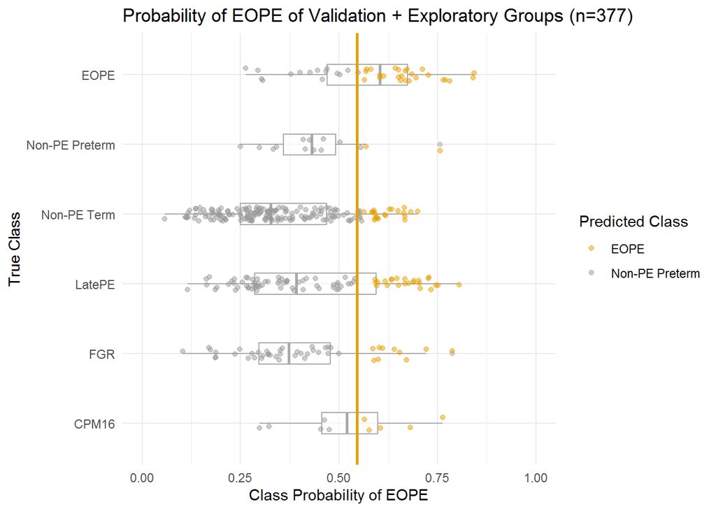

```r
meta$EOPE_5 <- c(valMeta$EOPE_5, expMeta$EOPE_5)
meta$nPTB_5 <- c(valMeta$nPTB_5 , expMeta$nPTB_5)

meta <- meta %>% mutate(Pred_Class_5 = case_when(EOPE_5 > 0.5594305 ~ "EOPE",
                                                 EOPE_5 < 0.5594305 ~ "Non-PE Preterm"))

meta %>%
  mutate(True_Class = factor(Class,
                             levels=c("CPM16", "FGR", "LatePE", "Non-PE Term", "Non-PE Preterm", "EOPE"))) %>%
  ggplot() +
  geom_boxplot(aes(x = True_Class,
                  y = EOPE_5),
               width=0.3,
               alpha=0.5,
               color="darkgrey") +
  geom_jitter(aes(x = True_Class,
                  y = EOPE_5,
                  color = Pred_Class_5),
              alpha = 0.5,
              position = position_jitter(width = .1)) +
  coord_flip() +
  ylab("Class Probability of EOPE") +
  xlab("True Class") +
  ylim(0,1) +
  scale_color_manual(name = "Predicted Class", values=c("#E69F00", "#999999")) +
  theme_minimal() +
  geom_hline(yintercept = 0.5454187,
             color = "#E69F00", size=1) +
  ggtitle("Probability of EOPE of Validation + Exploratory Groups (n=377)")
```

```r
ggsave(file="FigureSupp_5CpgProbs.png",
       width=10, height=3.5,
       path = here::here("Output", "2022_Manuscript"),
       bg = "transparent",
       dpi=500)

MAE(meta$EOPE_5, meta$EOPE)
```

```
## [1] 0.04132506
```

# Cell composition and ancestry (Figure 4)

## Boxplots of cell compositions of EOPE vs. nPTB samples before, using the true labels, and after, using eoPred-assigned labels (in training vs. validation & exploratory cohorts)

### Training

```r
# cell composition of samples before and after
celltypes_Train <- trainMeta %>%
  dplyr::select(Class, Trophoblasts, Stromal, Hofbauer, Endothelial, nRBC, Syncytiotrophoblast) %>%
  pivot_longer(!Class, names_to="cell_type")


# followed this tutorial https://www.datanovia.com/en/blog/how-to-perform-multiple-paired-t-tests-in-r/
celltypes_Train$cell_type <- factor(celltypes_Train$cell_type, levels = c("Hofbauer", "nRBC", "Stromal", "Endothelial", "Trophoblasts", "Syncytiotrophoblast"))

stat <-
celltypes_Train %>%
  group_by(cell_type) %>%
  rstatix::pairwise_t_test(
    value ~ Class,
    p.adjust.method = "bonferroni"
      )

head(stat)
```

```
## # A tibble: 6 x 10
##   cell_type      .y.   group1 group2    n1    n2       p p.sig~1   p.adj p.adj~2
##   <fct>          <chr> <chr>  <chr>  <int> <int>   <dbl> <chr>     <dbl> <chr>
## 1 Hofbauer       value EOPE   Non-P~    42    41 1.42e-4 ***     1.42e-4 ***
## 2 nRBC           value EOPE   Non-P~    42    41 7.03e-1 ns      7.03e-1 ns
## 3 Stromal        value EOPE   Non-P~    42    41 4.67e-5 ****    4.67e-5 ****
## 4 Endothelial    value EOPE   Non-P~    42    41 3.74e-1 ns      3.74e-1 ns
## 5 Trophoblasts   value EOPE   Non-P~    42    41 2.86e-1 ns      2.86e-1 ns
## 6 Syncytiotroph~ value EOPE   Non-P~    42    41 2.74e-1 ns      2.74e-1 ns
## # ... with abbreviated variable names 1: p.signif, 2: p.adj.signif
```

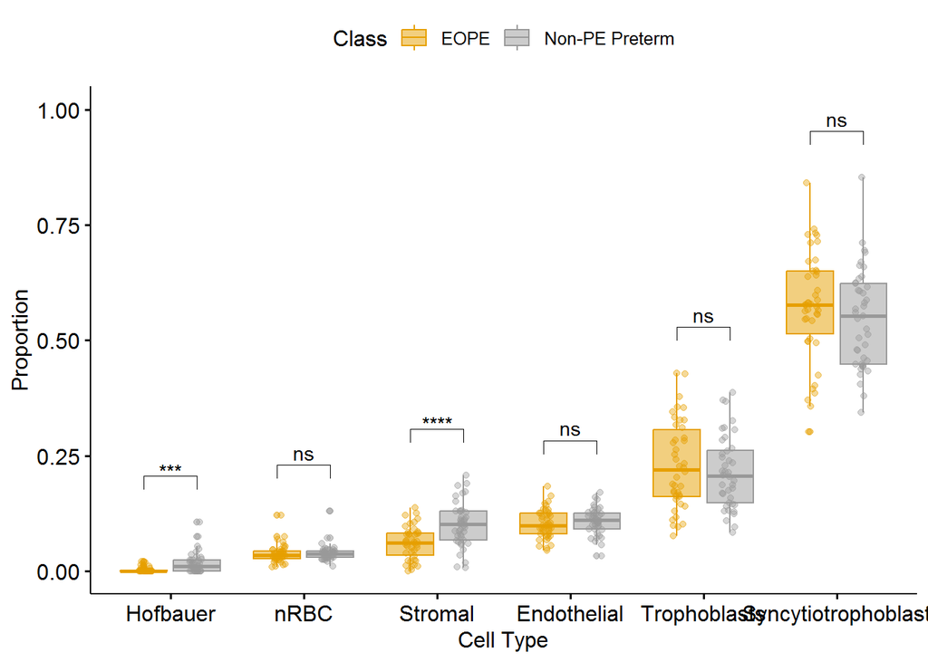

```r
bxp <- ggboxplot(
  celltypes_Train, x = "cell_type", y = "value",
  color="Class", palette=c("#E69F00", "#999999"),
  fill="Class", alpha=0.5
  )

# Add statistical test p-values
stat.test <- stat %>% add_xy_position(x = "cell_type")

bxp + stat_pvalue_manual(
  stat.test, label = "p.adj.signif",
  step.increase = 0
  ) +
  geom_point(position = position_jitterdodge(jitter.width = 0.2),
             aes(color = factor(Class)), show.legend = FALSE, alpha = 0.4) +
  xlab("Cell Type") +
  ylab("Proportion") +
  ylim(0,1)
```

```r
ggsave(file="FigureSupp_CellComposition_Training.png",
       width=10, height=3,
       path = here::here("Output", "2022_Manuscript"),
       bg = "transparent",
       dpi=500)
```

### Validation

```r
##### 1: ORIGINAL LABELS ######
celltypes_Val <- meta %>%
  filter(Group == "Validation") %>%
  dplyr::select(Class, Trophoblasts, Stromal, Hofbauer, Endothelial, nRBC, Syncytiotrophoblast) %>%
  pivot_longer(!Class, names_to="cell_type")

# followed this tutorial https://www.datanovia.com/en/blog/how-to-perform-multiple-paired-t-tests-in-r/
celltypes_Val$cell_type <- factor(celltypes_Val$cell_type, levels = c("Hofbauer", "nRBC", "Stromal", "Endothelial", "Trophoblasts", "Syncytiotrophoblast"))

stat <-
celltypes_Val %>%
  group_by(cell_type) %>%
  rstatix::pairwise_t_test(
    value ~ Class,
    p.adjust.method = "bonferroni"
      )

head(stat)
```

```
## # A tibble: 6 x 10
##   cell_type      .y.   group1 group2    n1    n2       p p.sig~1   p.adj p.adj~2
##   <fct>          <chr> <chr>  <chr>  <int> <int>   <dbl> <chr>     <dbl> <chr>
## 1 Hofbauer       value EOPE   Non-P~    38    11 0.681   ns      0.681   ns
## 2 nRBC           value EOPE   Non-P~    38    11 0.134   ns      0.134   ns
## 3 Stromal        value EOPE   Non-P~    38    11 0.00152 **      0.00152 **
## 4 Endothelial    value EOPE   Non-P~    38    11 0.897   ns      0.897   ns
## 5 Trophoblasts   value EOPE   Non-P~    38    11 0.157   ns      0.157   ns
## 6 Syncytiotroph~ value EOPE   Non-P~    38    11 0.561   ns      0.561   ns
## # ... with abbreviated variable names 1: p.signif, 2: p.adj.signif
```

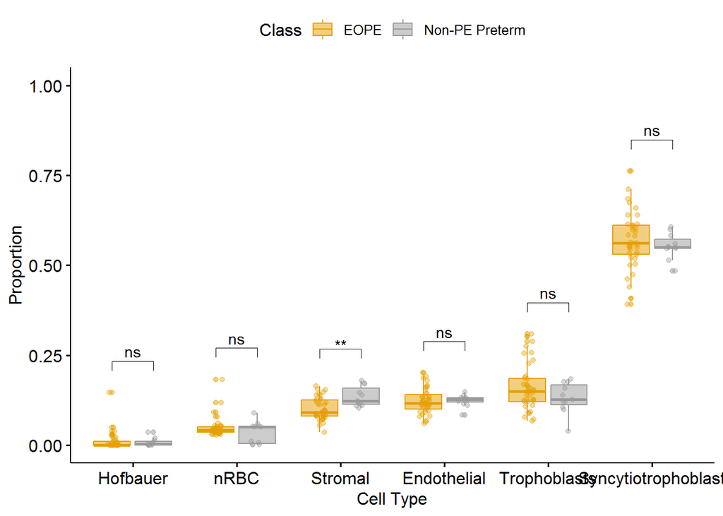

```r
bxp <- ggboxplot(
  celltypes_Val, x = "cell_type", y = "value",
  color="Class", palette=c("#E69F00", "#999999"),
  fill="Class", alpha=0.5
  )

# Add statistical test p-values
stat.test <- stat %>% add_xy_position(x = "cell_type")

bxp + stat_pvalue_manual(
  stat.test, label = "p.adj.signif",
  step.increase = 0
  ) +
  geom_point(position = position_jitterdodge(jitter.width = 0.2),
             aes(color = factor(Class)), show.legend = FALSE, alpha = 0.4) +
  xlab("Cell Type") +
  ylab("Proportion") +
  ylim(0,1)
```

```r
ggsave(file="FigureSupp_CellComposition_Validation.png",
       width=10, height=3,
       path = here::here("Output", "2022_Manuscript"),
       bg = "transparent",
       dpi=500)
##### 2: eoPred-assigned Labels #####
celltypes_Val <- meta %>%
  filter(Group == "Validation") %>%
  dplyr::select(Pred_Class_Best, Trophoblasts, Stromal, Hofbauer, Endothelial, nRBC, Syncytiotrophoblast) %>%
  pivot_longer(!Pred_Class_Best, names_to="cell_type")

# followed this tutorial https://www.datanovia.com/en/blog/how-to-perform-multiple-paired-t-tests-in-r/
celltypes_Val$cell_type <- factor(celltypes_Val$cell_type, levels = c("Hofbauer", "nRBC", "Stromal", "Endothelial", "Trophoblasts", "Syncytiotrophoblast"))

stat <-
celltypes_Val %>%
  group_by(cell_type) %>%
  rstatix::pairwise_t_test(
    value ~ Pred_Class_Best,
    p.adjust.method = "bonferroni"
      )

head(stat)
```

```
## # A tibble: 6 x 10
##   cell_type        .y.   group1 group2    n1    n2      p p.sig~1  p.adj p.adj~2
##   <fct>            <chr> <chr>  <chr>  <int> <int>  <dbl> <chr>    <dbl> <chr>
## 1 Hofbauer         value EOPE   Non-P~    24    25 0.0282 *       0.0282 *
## 2 nRBC             value EOPE   Non-P~    24    25 0.816  ns      0.816  ns
## 3 Stromal          value EOPE   Non-P~    24    25 0.0898 ns      0.0898 ns
## 4 Endothelial      value EOPE   Non-P~    24    25 0.264  ns      0.264  ns
## 5 Trophoblasts     value EOPE   Non-P~    24    25 0.998  ns      0.998  ns
## 6 Syncytiotrophob~ value EOPE   Non-P~    24    25 0.549  ns      0.549  ns
## # ... with abbreviated variable names 1: p.signif, 2: p.adj.signif
```

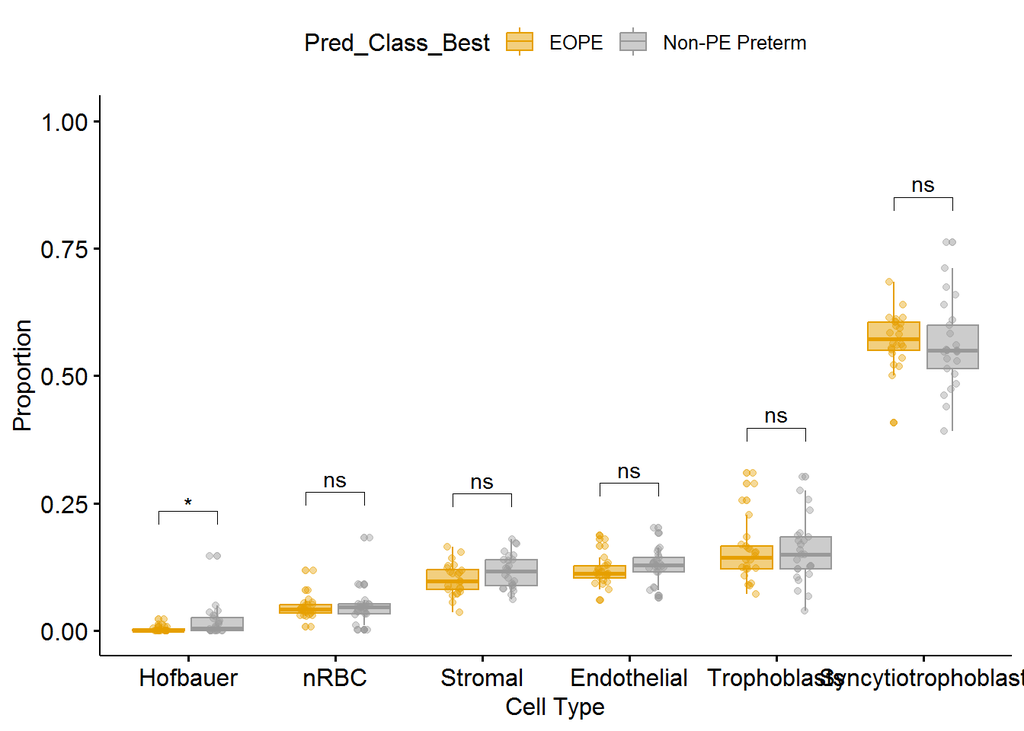

```r
bxp <- ggboxplot(
  celltypes_Val, x = "cell_type", y = "value",
  color="Pred_Class_Best", palette=c("#E69F00", "#999999"),
  fill="Pred_Class_Best", alpha=0.5
  )

# Add statistical test p-values
stat.test <- stat %>% add_xy_position(x = "cell_type")

bxp + stat_pvalue_manual(
  stat.test, label = "p.adj.signif",
  step.increase = 0
  ) +
  geom_point(position = position_jitterdodge(jitter.width = 0.2),
             aes(color = factor(Pred_Class_Best)), show.legend = FALSE, alpha = 0.4) +
  xlab("Cell Type") +
  ylab("Proportion") +
  ylim(0,1)
```

```r
ggsave(file="FigureSupp_CellComposition_Validation_eoPredlabels.png",
       width=10, height=3,
       path = here::here("Output", "2022_Manuscript"),
       bg = "transparent",
       dpi=500)
```

## Model probability against cell composition within EOPE and within nPTB

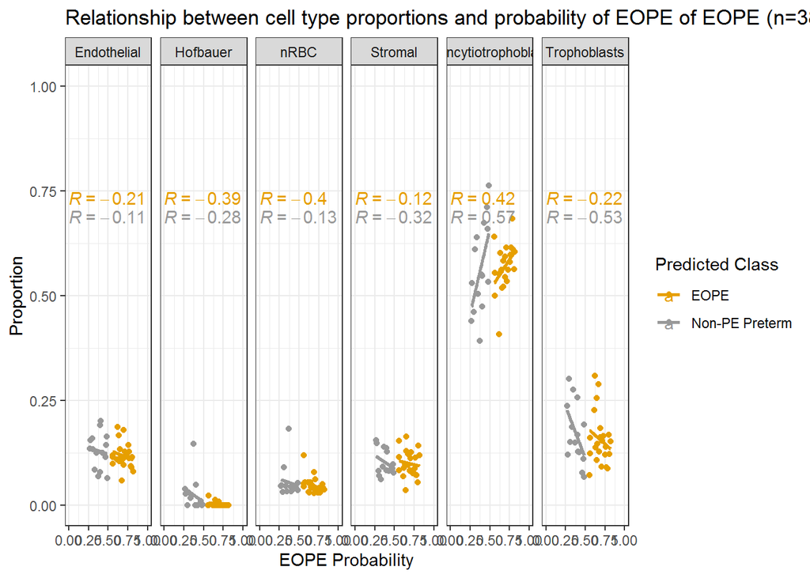

```r
meta %>%
  filter(Group == "Validation" & Class == "EOPE") %>%
  dplyr::select(Pred_Class_Best, EOPE,
                Syncytiotrophoblast, Trophoblasts, Endothelial, Stromal, Hofbauer, nRBC) %>%
  pivot_longer(!c(Pred_Class_Best, EOPE),
               values_to = "Proportion", names_to = "Cell Type") %>%
  arrange(factor(`Cell Type`, levels=c("Syncytiotrophoblast",
                                       "Trophoblasts",
                                       "Endothelial",
                                       "Stromal",
                                       "Hofbauer",
                                       "nRBC"))) %>%
  ggplot(aes(x=EOPE, y=Proportion, color=Pred_Class_Best)) +
  geom_point() +
  geom_smooth(method="lm", se=FALSE) +
  facet_wrap(~`Cell Type`, nrow=1) +
  scale_color_manual(name = "Predicted Class", values=c("#E69F00", "#999999"))  +
  coord_cartesian(xlim=c(0,1), ylim=c(0,1)) +
  theme_bw() +
  stat_cor(aes(label = ..r.label..), label.x=0) +
  xlab("EOPE Probability") +
  ggtitle("Relationship between cell type proportions and probability of EOPE of EOPE (n=38) samples in validation group")
```

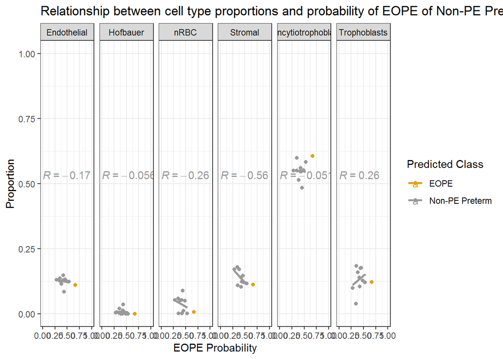

```r
ggsave(file="Figure4A.png",
       width=15, height=3,
       path = here::here("Output", "2022_Manuscript"),
       bg = "transparent",
       dpi=500)
meta %>%
  filter(Group == "Validation" & Class == "Non-PE Preterm") %>%
  dplyr::select(Pred_Class_Best, EOPE,
                Syncytiotrophoblast, Trophoblasts, Endothelial, Stromal, Hofbauer, nRBC) %>%
  pivot_longer(!c(Pred_Class_Best, EOPE),
               values_to = "Proportion", names_to = "Cell Type") %>%
  arrange(factor(`Cell Type`, levels=c("Syncytiotrophoblast",
                                       "Trophoblasts",
                                       "Endothelial",
                                       "Stromal",
                                       "Hofbauer",
                                       "nRBC"))) %>%
  ggplot(aes(x=EOPE, y=Proportion, color=Pred_Class_Best)) +
  geom_point() +
  geom_smooth(method="lm", se=FALSE) +
  facet_wrap(~`Cell Type`, nrow=1) +
  scale_color_manual(name = "Predicted Class", values=c("#E69F00", "#999999"))  +
  coord_cartesian(xlim=c(0,1), ylim=c(0,1)) +
  theme_bw() +
  stat_cor(aes(label = ..r.label..), label.x=0) +
  xlab("EOPE Probability") +
  ggtitle("Relationship between cell type proportions and probability of EOPE of Non-PE Preterm (n=11) samples in validation group")
```

```r
ggsave(file="FigureSupp_CellCompositionEOPEProb.png",
       width=15, height=3,
       path = here::here("Output", "2022_Manuscript"),
       bg = "transparent",
       dpi=500)
```

## Look at average beta value of 45 predictive probes by ancestry, within each class (EOPE, nPTB)

### Original classes

**Boxplot:**

```r
tabyl(meta %>% filter(Group == "Validation"), Predicted_ethnicity_nothresh, Class)
```

```
##  Predicted_ethnicity_nothresh EOPE Non-PE Preterm
##                       African    5              0
##                         Asian   26              2
##                     Caucasian    7              9
```

```r
tabyl(trainMeta, Predicted_ethnicity_nothresh, Class)
```

```
##  Predicted_ethnicity_nothresh EOPE Non-PE Preterm
##                       African    7              5
##                         Asian    7              6
##                     Caucasian   28             30
```

```r
dim(long_predictors)
```

```
## [1] 16965    41
```

```r
dim(long_trainPredictors)
```

```
## [1] 3735   34
```

```r
colnames(long_predictors)
```

```
##  [1] "cpg"                          "Sample_ID"
##  [3] "beta"                         "Subject_ID"
##  [5] "GEO_Dataset"                  "Sex"
##  [7] "Condition"                    "IUGR"
##  [9] "Preterm"                      "Term"
## [11] "PE"                           "GA"
## [13] "GA_RPC"                       "Ethnicity"
## [15] "Maternal_Age"                 "Chip"
## [17] "Row"                          "Column"
## [19] "Predicted_ethnicity_nothresh" "Predicted_ethnicity"
## [21] "Prob_African"                 "Prob_Asian"
## [23] "Prob_Caucasian"               "Highest_Prob"
## [25] "Class"                        "X"
## [27] "Y"                            "DNAme_Sex"
## [29] "FAIL_DNAme_Sex"               "EOPE"
## [31] "Non-PE Preterm"               "Pred_Class"
## [33] "Trophoblasts"                 "Stromal"
## [35] "Hofbauer"                     "Endothelial"
## [37] "nRBC"                         "Syncytiotrophoblast"
## [39] "Group"                        "Pred_Class_60"
## [41] "Pred_Class_Best"
```

```r
colnames(long_trainPredictors)
```

```
##  [1] "cpg"                          "Sample_ID"
##  [3] "beta"                         "X"
##  [5] "Subject_ID"                   "GEO_Dataset"
##  [7] "Sex"                          "Condition"
##  [9] "IUGR"                         "Preterm"
## [11] "Term"                         "PE"
## [13] "GA"                           "GA_RPC"
## [15] "Ethnicity"                    "Maternal_Age"
## [17] "Chip"                         "Row"
## [19] "Column"                       "Predicted_ethnicity_nothresh"
## [21] "Predicted_ethnicity"          "Prob_African"
## [23] "Prob_Asian"                   "Prob_Caucasian"
## [25] "Highest_Prob"                 "mMed"
## [27] "uMed"                         "Class"
## [29] "Trophoblasts"                 "Stromal"
## [31] "Hofbauer"                     "Endothelial"
## [33] "nRBC"                         "Syncytiotrophoblast"
```

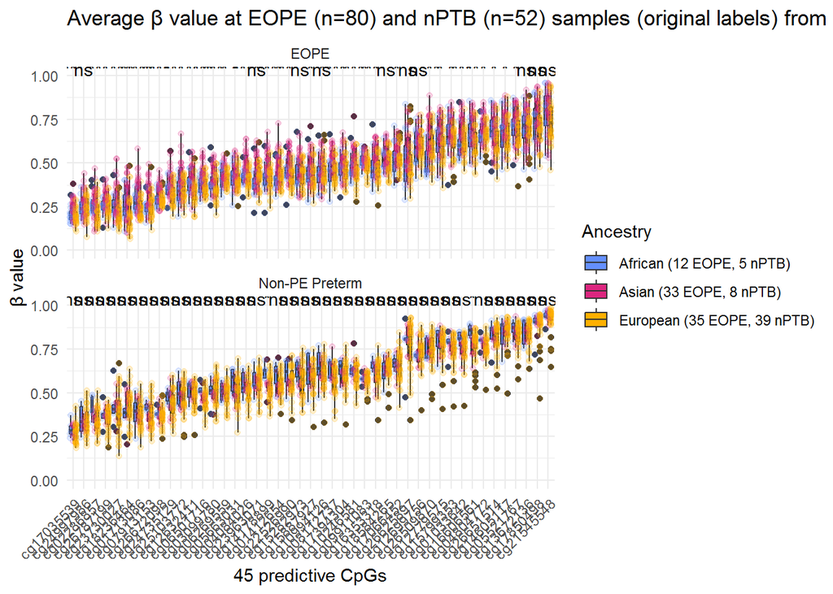

```r
x <- long_predictors %>% dplyr::select(cpg, beta, Class, Predicted_ethnicity_nothresh)
y <- long_trainPredictors %>% dplyr::select(cpg, beta, Class, Predicted_ethnicity_nothresh)
z <- rbind(x, y)

z %>%
  filter(Class %in% c("EOPE", "Non-PE Preterm")) %>%
  filter(!is.na(Predicted_ethnicity_nothresh)) %>%
  mutate(Ancestry = case_when(Predicted_ethnicity_nothresh == "African" ~ "African (12 EOPE, 5 nPTB)",
                              Predicted_ethnicity_nothresh == "Asian" ~ "Asian (33 EOPE, 8 nPTB)",
                              Predicted_ethnicity_nothresh == "Caucasian" ~ "European (35 EOPE, 39 nPTB)")) %>%
  ggplot(aes(x=reorder(cpg, beta), y=beta, fill=Ancestry))+
  geom_boxplot() +
  geom_boxplot(alpha = 0.5) +
  geom_point(position = position_jitterdodge(jitter.width = 0.2),
             aes(color = factor(Ancestry)), show.legend = FALSE, alpha = 0.2) +
  scale_color_manual(name = "Ancestry", values=c("#648FFF", "#DC267F", "#FFB000")) +
  scale_fill_manual(name = "Ancestry", values=c("#648FFF", "#DC267F", "#FFB000")) +
  facet_wrap(~Class, ncol=1) +
  ylab("\u03b2 value") +
  ylim(0,1) +
  xlab("45 predictive CpGs") +
  stat_compare_means(label="p.signif") +
  theme_minimal() +
  theme(axis.text.x = element_text(angle=45, hjust=1)) +
  ggtitle("Average \u03b2 value at EOPE (n=80) and nPTB (n=52) samples (original labels) from the training and validation groups")
```

```r
ggsave(file="FigureSupp_AncestryOriginalLabels_BetaValues.png",
       width=15, height=6,
       path = here::here("Output", "2022_Manuscript"),
       bg = "transparent",
       dpi=500)
```

**Density plot:**

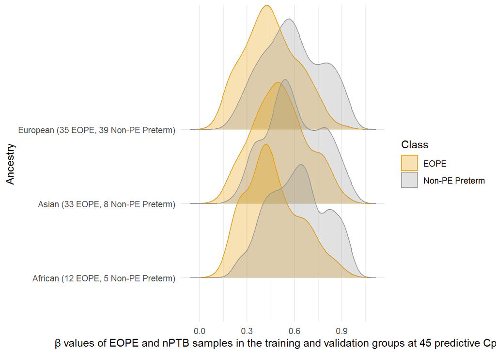

```r
z %>%
  filter(Class %in% c("EOPE", "Non-PE Preterm")) %>%
  filter(!is.na(Predicted_ethnicity_nothresh)) %>%
  mutate(Ancestry = case_when(Predicted_ethnicity_nothresh == "African" ~ "African (12 EOPE, 5 Non-PE Preterm)",
                              Predicted_ethnicity_nothresh == "Asian" ~ "Asian (33 EOPE, 8 Non-PE Preterm)",
                              Predicted_ethnicity_nothresh == "Caucasian" ~ "European (35 EOPE, 39 Non-PE Preterm)")) %>%
  ggplot(aes(x=beta, y=Ancestry, color=Class, fill=Class))+
  geom_density_ridges(alpha=0.3) +
  scale_color_manual(name = "Class", values=c("#E69F00", "#999999")) +
  scale_fill_manual(name = "Class", values=c("#E69F00", "#999999")) +
  xlab("\u03b2 values of EOPE and nPTB samples in the training and validation groups at 45 predictive CpGs") +
  theme_minimal()
```

```r
ggsave(file="FigureSupp_Ancestry_Density.png",
       width=12, height=3,
       path = here::here("Output", "2022_Manuscript"),
       bg = "transparent",
       dpi=500)
```

### Predicted classes

**Boxplot:**

```r
tabyl(meta, Predicted_ethnicity_nothresh, Pred_Class)
```

```
##  Predicted_ethnicity_nothresh EOPE Non-PE Preterm
##                       African   14             43
##                         Asian   19             69
##                     Caucasian   60            171
##                          <NA>    0              1
```

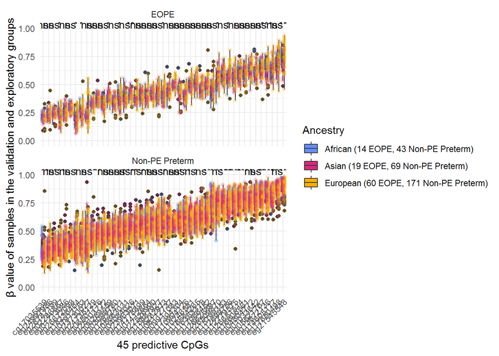

```r
long_predictors %>%
  filter(!is.na(Predicted_ethnicity_nothresh)) %>%
  mutate(Ancestry = case_when(Predicted_ethnicity_nothresh == "African" ~ "African (14 EOPE, 43 Non-PE Preterm)",
                              Predicted_ethnicity_nothresh == "Asian" ~ "Asian (19 EOPE, 69 Non-PE Preterm)",
                              Predicted_ethnicity_nothresh == "Caucasian" ~ "European (60 EOPE, 171 Non-PE Preterm)")) %>%
  ggplot(aes(x=reorder(cpg, beta), y=beta, fill=Ancestry))+
  geom_boxplot() +
  geom_boxplot(alpha = 0.5) +
  geom_point(position = position_jitterdodge(jitter.width = 0.2),
             aes(color = factor(Ancestry)), show.legend = FALSE, alpha = 0.2) +
  scale_color_manual(name = "Ancestry", values=c("#648FFF", "#DC267F", "#FFB000")) +
  scale_fill_manual(name = "Ancestry", values=c("#648FFF", "#DC267F", "#FFB000")) +
  facet_wrap(~Pred_Class_Best, ncol=1) +
  ylab("\u03b2 value of samples in the validation and exploratory groups") +
  ylim(0,1) +
  xlab("45 predictive CpGs") +
  stat_compare_means(label="p.signif") +
  theme_minimal() +
  theme(axis.text.x = element_text(angle=45, hjust=1))
```

```r
ggsave(file="FigureSupp_AncestryPredLabels_BetaValues.png",
       width=15, height=6,
       path = here::here("Output", "2022_Manuscript"),
       bg = "transparent",
       dpi=500)
```

**Density plot:**

[figure not shown]

```r
long_predictors %>%
  filter(!is.na(Predicted_ethnicity_nothresh)) %>%
  mutate(Ancestry = case_when(Predicted_ethnicity_nothresh == "African" ~ "African (12 EOPE, 5 Non-PE Preterm)",
                              Predicted_ethnicity_nothresh == "Asian" ~ "Asian (33 EOPE, 8 Non-PE Preterm)",
                              Predicted_ethnicity_nothresh == "Caucasian" ~ "European (35 EOPE, 39 Non-PE Preterm)")) %>%
  ggplot(aes(x=beta, y=Ancestry, color=Pred_Class_Best, fill=Pred_Class_Best)) +
  geom_density_ridges(alpha=0.3) +
  scale_color_manual(name = "Class", values=c("#E69F00", "#999999")) +
  scale_fill_manual(name = "Class", values=c("#E69F00", "#999999")) +
  xlab("\u03b2 values of all samples in the validation and exploratory groups at 45 predictive CpGs") +
  theme_minimal()
```

```r
ggsave(file="FigureSupp_Ancestry_Density_2.png",
       width=12, height=3,
       path = here::here("Output", "2022_Manuscript"),
       bg = "transparent",
       dpi=500)
```

```r
tabyl(meta, Predicted_ethnicity_nothresh, Pred_Class)
```

```
##  Predicted_ethnicity_nothresh EOPE Non-PE Preterm
##                       African   14             43
##                         Asian   19             69
##                     Caucasian   60            171
##                          <NA>    0              1
```

```r
head(long_predictors)
```

```
##          cpg  Sample_ID      beta Subject_ID GEO_Dataset    Sex   Condition
## 1 cg10246581 GSM1388230 0.6527898       <NA>    GSE57767 Female Non-PE Term
## 2 cg09911083 GSM1388230 0.6301145       <NA>    GSE57767 Female Non-PE Term
## 3 cg18584265 GSM1388230 0.6591328       <NA>    GSE57767 Female Non-PE Term
## 4 cg12632411 GSM1388230 0.5669558       <NA>    GSE57767 Female Non-PE Term
## 5 cg07913153 GSM1388230 0.3855307       <NA>    GSE57767 Female Non-PE Term
## 6 cg10994126 GSM1388230 0.6079692       <NA>    GSE57767 Female Non-PE Term
##      IUGR Preterm Term PE GA   GA_RPC Ethnicity Maternal_Age Chip  Row Column
## 1 Unknown      No  Yes No NA 38.37877      <NA>           NA   NA <NA>   <NA>
## 2 Unknown      No  Yes No NA 38.37877      <NA>           NA   NA <NA>   <NA>
## 3 Unknown      No  Yes No NA 38.37877      <NA>           NA   NA <NA>   <NA>
## 4 Unknown      No  Yes No NA 38.37877      <NA>           NA   NA <NA>   <NA>
## 5 Unknown      No  Yes No NA 38.37877      <NA>           NA   NA <NA>   <NA>
## 6 Unknown      No  Yes No NA 38.37877      <NA>           NA   NA <NA>   <NA>
##   Predicted_ethnicity_nothresh Predicted_ethnicity Prob_African  Prob_Asian
```

[output cut: 34 more lines]

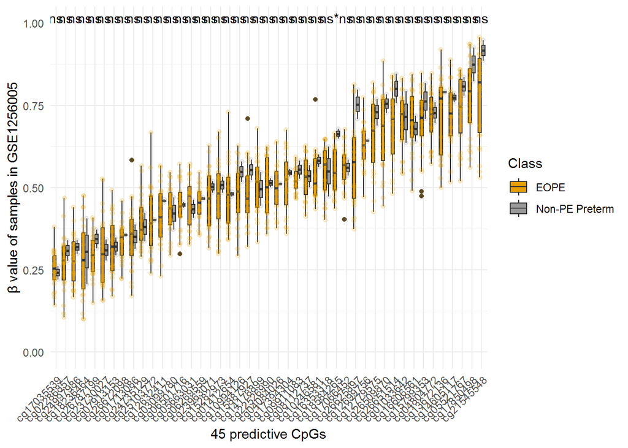

```r
long_predictors %>%
  filter(!is.na(Predicted_ethnicity_nothresh)) %>%
  mutate(Ancestry = case_when(Predicted_ethnicity_nothresh == "African" ~ "African (14 EOPE, 43 Non-PE Preterm)",
                              Predicted_ethnicity_nothresh == "Asian" ~ "Asian (19 EOPE, 69 Non-PE Preterm)",
                              Predicted_ethnicity_nothresh == "Caucasian" ~ "European (60 EOPE, 171 Non-PE Preterm)")) %>%
  filter(Ancestry == "Asian (19 EOPE, 69 Non-PE Preterm)") %>%
  filter(Class %in% c("EOPE", "Non-PE Preterm")) %>%
  ggplot(aes(x=reorder(cpg, beta), y=beta, fill=Class))+
  geom_boxplot() +
  geom_point(position = position_jitterdodge(jitter.width = 0.2),
             aes(color = factor(Class)), show.legend = FALSE, alpha = 0.2) +
  scale_color_manual(name = "Class", values=c("#E69F00", "#999999")) +
  scale_fill_manual(name = "Class", values=c("#E69F00", "#999999")) +
  ylab("\u03b2 value of samples in GSE1256005") +
  ylim(0,1) +
  xlab("45 predictive CpGs") +
  stat_compare_means(label="p.signif") +
  theme_minimal() +
  theme(axis.text.x = element_text(angle=45, hjust=1))
```

```r
ggsave(file="FigureSupp_AncestryPredLabels_BetaValues.png",
       width=15, height=6,
       path = here::here("Output", "2022_Manuscript"),
       bg = "transparent",
       dpi=500)
```

# Predictor analysis (Figure 5)

## Chromosome by chromosome

```r
predictorsInfo <- probeInfo %>% filter(probeID %in% predictors)
tabyl(predictorsInfo, chr)
```

```
##    chr n    percent
##   chr1 7 0.15555556
##  chr10 1 0.02222222
##  chr11 2 0.04444444
##  chr12 1 0.02222222
##  chr13 3 0.06666667
##  chr16 5 0.11111111
##  chr17 3 0.06666667
##  chr19 2 0.04444444
##   chr2 3 0.06666667
##  chr20 3 0.06666667
##  chr22 1 0.02222222
##   chr3 5 0.11111111
##   chr4 1 0.02222222
##   chr6 4 0.08888889
##   chr7 1 0.02222222
##   chr8 3 0.06666667
```

```r
# following tutorial https://bernatgel.github.io/karyoploter_tutorial//Examples/CpGIslands/CpGIslands.html
ahub <- AnnotationHub()
```

```
## snapshotDate(): 2021-10-20
```

```r
cpgs <- ahub[["AH5086"]]
```

```
## loading from cache
```

```r
head(cpgs)
```

```
## GRanges object with 6 ranges and 1 metadata column:
##       seqnames        ranges strand |        name
##          <Rle>     <IRanges>  <Rle> | <character>
##   [1]     chr1   28736-29810      * |    CpG:_116
##   [2]     chr1 135125-135563      * |     CpG:_30
##   [3]     chr1 327791-328229      * |     CpG:_29
##   [4]     chr1 437152-438164      * |     CpG:_84
##   [5]     chr1 449274-450544      * |     CpG:_99
##   [6]     chr1 533220-534114      * |     CpG:_94
##   -------
##   seqinfo: 93 sequences (1 circular) from hg19 genome
```

```r
# plot chr1, chr3, chr6, chr16 chr with >3 CpGs)

# chr1
chr1_preds <- predictorsInfo %>% filter(chr=="chr1")
chr1_preds
```

```
##      probeID  chr       pos strand       Name AddressA AddressB
## 1 cg07913153 chr1 236680761      + cg07913153 68641333
## 2 cg10994126 chr1 176432498      + cg10994126 64767485
## 3 cg14178899 chr1   8076599      - cg14178899 32701319
## 4 cg17035539 chr1 229544326      - cg17035539 31741374
## 5 cg17850498 chr1  21565755      - cg17850498 21793477
## 6 cg18236464 chr1 176528783      + cg18236464 44770411
## 7 cg25103772 chr1 176513705      - cg25103772 38619460
##                                            ProbeSeqA ProbeSeqB Type NextBase
## 1 AAAAACTTCCCTCAACAAAACAATCTCAATATTTAACCAACCCTTCCAAC             II
## 2 TTTTACTCCTTAATCACTATCACAAACAATTAATACTACCATTAATACTC             II
## 3 ACAAAATAAATACATTTTTCTTAAATTAATAATTCCTCAACTTCAAAACC             II
## 4 ACCAAATCTCTCTCAACCRAACTAAAAACCCTAAACAAAACTCAAATTCC             II
## 5 CCRAAAATAAACRTCTATAAACTACAACCTCCTAAACATAACCCAAAAAC             II
## 6 ATAAATAAAAACCAACCATCRTAAAAATAAACAATAACCAACTCAAAAAC             II
## 7 TATTTTTCTTTATATTCATATACAATACCTCTAACCACCAATTAAATAAC             II
##   Color
## 1
## 2
## 3
## 4
## 5
## 6
## 7
##                                                                                                               Forward_Sequence
## 1 GGTTTTACTTGTTGCTTTACAATGAACTGTGTAAACACAAGCTGGAAGAGATCAGCTATG[CG]CTGGAAGGGTTGGTTAAATATTGAGACTGCCTTGCTGAGGGAAGCCTTTTAATGAATCTC
## 2 GAGCCTGGACGCCAGCCAGGATTGAGGTCCTACGGGTGTTTGGGGACCTCCCCAAGCCCA[CG]AGTATCAATGGCAGTATCAATTGTCTGTGACAGTGATTAAGGAGCAAAACACTTGGTATG
## 3 AGGCATGGATAACAAAATAAGTACATTTTTCTTAAATTAGTAGTTCCTCAACTTCAGGAC[CG]CCAATCCCCTTTGTCAGATGTTACAGGTCTGGAGTCCCTATAGCCCCCTTTTCACTTTCC
## 4 GCAGGCAGTGGGCCAGGTCTCTCTCAGCCGGGCTGAGGACCCTGGACAGAGCTCAGATTC[CG]GATACAGTTCCTCCACAGAGTGGGGTGGGAATCCGGGTGGGCCCCACCCACTGAGGCTCA
## 5 CTCTGTGCAAACCGGAAATAGGCGTCTGTGGGCTGCAACCTCCTGGGCATGGCCCAGGGA[CG]CGTGCTGGGCTAATGTCAGCCCCAGTCACTCCCCGGCCAGGCATCCCTCTGTGGACAGTA
## 6 CTAATCTACTCATGCCTGTGGACAGACCAGTCCATCTTCCTTCTCTTACCATACAGCACT[CG]CCCCTGAGCTGGTCATTGTCTATTCCTACGATGGCTGGCCTTCACCTATGCAGAATGACA
## 7 GAAATCCCGACTGTTTTTCTTTATATTCATATGCAATACCTCTGGCCACCAATTGAGTGG[CG]TTTTCTTTCACACCAAGCAATTCTTCAATTCTCTGTGGATGACAACTGGATGTCCTACAA
##                                            SourceSeq Random_Loci Methyl27_Loci
## 1 CGCTGGAAGGGTTGGTTAAATATTGAGACTGCCTTGCTGAGGGAAGCCTT
## 2 TTTGCTCCTTAATCACTGTCACAGACAATTGATACTGCCATTGATACTCG                      TRUE
## 3 CAAAATAAGTACATTTTTCTTAAATTAGTAGTTCCTCAACTTCAGGACCG
## 4 CGGAATCTGAGCTCTGTCCAGGGTCCTCAGCCCGGCTGAGAGAGACCTGG
## 5 CGGAAATAGGCGTCTGTGGGCTGCAACCTCCTGGGCATGGCCCAGGGACG
## 6 CGCCCCTGAGCTGGTCATTGTCTATTCCTACGATGGCTGGCCTTCACCTA
## 7 CGCCACTCAATTGGTGGCCAGAGGTATTGCATATGAATATAAAGAAAAAC
```

[output cut: 9 more lines]

```
## 1                     TSS1500
## 2 1stExon;5'UTR;1stExon;5'UTR
## 3                       5'UTR                 TRUE
## 4                                             TRUE
## 5         Body;Body;Body;Body                 TRUE
## 6                   Body;Body
## 7                 5'UTR;5'UTR                 TRUE
##   Regulatory_Feature_Name Regulatory_Feature_Group DHS
## 1
## 2
## 3
## 4
## 5
## 6   1:176528325-176529974             Unclassified
## 7
```

```r
png(here::here("Output", "2022_Manuscript", "FigureSupp_Chr1.png"),
    width = 2000, height = 600,
    pointsize = 12, bg = "transparent",
    res=200)
kp <- plotKaryotype(chromosomes="chr1")
kpAddBaseNumbers(kp)
kpPlotRegions(kp, data=cpgs, col="#CCCCCC44", border="#CCCCCC44", r0=0, r1=0.2)
kpPlotMarkers(kp, chr=chr1_preds$chr, x=chr1_preds$pos, labels=chr1_preds$probeID)
dev.off()
```

```r
# chr3
chr3_preds <- predictorsInfo %>% filter(chr=="chr3")
chr3_preds
```

```
##      probeID  chr       pos strand       Name AddressA AddressB
## 1 cg01412654 chr3  12328084      + cg01412654 49639345
## 2 cg05663031 chr3 187453721      - cg05663031 33778367
## 3 cg13672136 chr3  46477681      + cg13672136 18751476
## 4 cg17394304 chr3 187453973      - cg17394304 12620456
## 5 cg23730027 chr3  57995180      - cg23730027 70769478
##                                            ProbeSeqA ProbeSeqB Type NextBase
## 1 TCTTCCTTTCTTTTCTTTCTTTCTTCCATAAAACAAAATATTACTATATC             II
## 2 AACCTAAAACCAACAAAATCATATTAAACCATATACATAATTAATAACCC             II
## 3 ATATCCCACAACCCTCCTAAAAACCTATAAATTCCTCAAAAAATAAAACC             II
## 4 ACACTCTAACATTTCTCTATAATCCCAAATACCAATCACTCAATCCCATC             II
## 5 AATAAATATAAACCCCRAAATTACAAAAATAAACRCRAATATATATCCTC             II
##   Color
## 1
## 2
## 3
## 4
## 5
##                                                                                                               Forward_Sequence
## 1 TGAGCCCGGGAAGTCGAGGCTGAAGTGAGCCGTGATTGCGCCACAGCACTCCAGCCTGGG[CG]ACACAGCAACACCCTGTCTCATGGAAGAAAGAAAGAAAAGAAAGGAAGAAAGAAAAAAAA
## 2 CTGGGTAAAGAGGCCTGAGGCCAACAAGGTCATGTTGGGCCATGTACATGGTTGGTGACC[CG]GCCCTAGGTCTTCTGGCTCAAATTCCTGTCCCCTTTCCAAATCAGCCTACGTGCTGTAGA
## 3 GGAGAAGAGCTGGGGGCAGTGAATGGCTGAGGCTTTCTTGGGGAGCTGGGCCATCTTCTT[CG]GTTTTACTTCCTGAGGAATTCACAGGCTTCCAGGAGGGCTGTGGGACACAACAGAGCAAG
## 4 TCTGTAACCAAACACTCTGACATTTCTCTGTGGTCCCAAGTGCCAGTCACTCAATCCCAT[CG]GCTCCAAGGTTAGTGTGTGCATGTGAGTGAGTGGGGACTGGAGGGAAGGAAGTGGGGAAG
## 5 GCCGTCGCTGGAATGGGTGTGGGCCCCGAGGTTGCAAGGGTAGGCGCGGGTGTGTGTCCT[CG]CTCTCTCTGCTCCCAGCTCAGCTCTGGCCGCGCGCCGCAGGTTGAACCCACTCCTTGCTG
##                                            SourceSeq Random_Loci Methyl27_Loci
## 1 CTTCCTTTCTTTTCTTTCTTTCTTCCATGAGACAGGGTGTTGCTGTGTCG
## 2 GCCTGAGGCCAACAAGGTCATGTTGGGCCATGTACATGGTTGGTGACCCG
## 3 CGGTTTTACTTCCTGAGGAATTCACAGGCTTCCAGGAGGGCTGTGGGACA
## 4 CACTCTGACATTTCTCTGTGGTCCCAAGTGCCAGTCACTCAATCCCATCG
## 5 ATGGGTGTGGGCCCCGAGGTTGCAAGGGTAGGCGCGGGTGTGTGTCCTCG
##     UCSC_RefGene_Name                           UCSC_RefGene_Accession
## 1         PPARG;PPARG                              NM_005037;NM_138712
## 2      BCL6;BCL6;BCL6              NM_001706;NM_001130845;NM_001134738
## 3                 LTF                                        NM_002343
## 4 BCL6;BCL6;BCL6;BCL6 NM_001706;NM_001130845;NM_001130845;NM_001134738
## 5 FLNB;FLNB;FLNB;FLNB NM_001164319;NM_001164317;NM_001164318;NM_001457
##            UCSC_RefGene_Group Phantom DMR Enhancer          HMM_Island
## 1             TSS1500;TSS1500
## 2         5'UTR;5'UTR;TSS1500
## 3                       3'UTR
## 4 5'UTR;5'UTR;1stExon;TSS1500
## 5         Body;Body;Body;Body                      3:57968879-57970258
##   Regulatory_Feature_Name        Regulatory_Feature_Group DHS
## 1
## 2
## 3
## 4   3:187453901-187454110 Unclassified_Cell_type_specific
## 5
```

```r
png(here::here("Output", "2022_Manuscript", "FigureSupp_Chr3.png"),
    width = 2000, height = 600,
    pointsize = 12, bg = "transparent",
    res=200)
kp <- plotKaryotype(chromosomes="chr3")
kpAddBaseNumbers(kp)
kpPlotRegions(kp, data=cpgs, col="#CCCCCC44", border="#CCCCCC44", r0=0, r1=0.2)
kpPlotMarkers(kp, chr=chr3_preds$chr, x=chr3_preds$pos, labels=chr3_preds$probeID)
dev.off()
```

```r
# chr6
chr6_preds <- predictorsInfo %>% filter(chr=="chr6")
chr6_preds
```

```
##      probeID  chr      pos strand       Name AddressA AddressB
## 1 cg12699756 chr6 33173482      - cg12699756 59615343
## 2 cg17066452 chr6 33173501      - cg17066452 46771495
## 3 cg21545548 chr6 26296575      + cg21545548 14727416
## 4 cg23963071 chr6  2901712      + cg23963071 54666448
##                                            ProbeSeqA ProbeSeqB Type NextBase
## 1 AAACAAACTATACAACATCCAAAACTAAAATAATTAAACTAACCCAAACC             II
## 2 CAAAACTAAAATAATTAAACTAACCCAAACCRCAACCCRAAAACTTAAAC             II
## 3 CTCTAATACCCAAATAAACTTTACTATACAAACATAACTTACACACATAC             II
## 4 CRCCTATTTTACTCCTCACCTTAAACTATTTCTTACCTTTCCATTCTAAC             II
##   Color
## 1
## 2
## 3
## 4
##                                                                                                               Forward_Sequence
## 1 GAACGTGGGGCAGACAAACTATGCAGCATCCAAGGCTGGAGTGATTGGGCTGACCCAGAC[CG]CAGCCCGGGAGCTTGGACGGTTGGTCAGATGCTTGAGGGTGCTGGGGAGCACCTGGGGGG
## 2 TATGCAGCATCCAAGGCTGGAGTGATTGGGCTGACCCAGACCGCAGCCCGGGAGCTTGGA[CG]GTTGGTCAGATGCTTGAGGGTGCTGGGGAGCACCTGGGGGGTCTGAGGGAGGTACCAGCA
## 3 TTCTCATCCAACGTCTTCACTGAGGATAGGAAAGCCCTTTCTCTCCAATTGTGAACTGCA[CG]CATGTGTGTAAGCTATGCTTGCATAGCAAAGTCCACTTGGGCATTAGAGTCAAAGTTGTT
## 4 TCCCAGCAAAAGCCATGAGTGTAGATTGTGCGTGAGAGGAAGGATCTGATCCCTGCAGAA[CG]CCAGAATGGAAAGGCAAGAAACAGCCCAAGGTGAGGAGTAAAACAGGCGAGAACAAGGAG
##                                            SourceSeq Random_Loci Methyl27_Loci
## 1 GACAAACTATGCAGCATCCAAGGCTGGAGTGATTGGGCTGACCCAGACCG
## 2 AAGGCTGGAGTGATTGGGCTGACCCAGACCGCAGCCCGGGAGCTTGGACG
## 3 CGCATGTGTGTAAGCTATGCTTGCATAGCAAAGTCCACTTGGGCATTAGA
## 4 CGCCAGAATGGAAAGGCAAGAAACAGCCCAAGGTGAGGAGTAAAACAGGC
##   UCSC_RefGene_Name UCSC_RefGene_Accession UCSC_RefGene_Group Phantom DMR
## 1           HSD17B8              NM_014234               Body
## 2           HSD17B8              NM_014234               Body
## 3
## 4          SERPINB9              NM_004155              5'UTR
##   Enhancer HMM_Island Regulatory_Feature_Name Regulatory_Feature_Group  DHS
## 1                         6:33171945-33173651      Promoter_Associated TRUE
## 2                         6:33171945-33173651      Promoter_Associated TRUE
## 3     TRUE
## 4
```

```r
png(here::here("Output", "2022_Manuscript", "FigureSupp_Chr6.png"),
    width = 2000, height = 600,
    pointsize = 12, bg = "transparent",
    res=200)
kp <- plotKaryotype(chromosomes="chr6")
kpAddBaseNumbers(kp)
kpPlotRegions(kp, data=cpgs, col="#CCCCCC44", border="#CCCCCC44", r0=0, r1=0.2)
kpPlotMarkers(kp, chr=chr6_preds$chr, x=chr6_preds$pos, labels=chr6_preds$probeID)
dev.off()
```

```r
# chr16
chr16_preds <- predictorsInfo %>% filter(chr=="chr16")
chr16_preds
```

```
##      probeID   chr      pos strand       Name AddressA AddressB
## 1 cg10246581 chr16 81536171      - cg10246581 71679461 24717498
## 2 cg01033642 chr16 81564192      - cg01033642 10600502
## 3 cg04084026 chr16 57832309      + cg04084026 26748360
## 4 cg16353318 chr16 81564161      - cg16353318 58697440
## 5 cg26787199 chr16  2044042      - cg26787199 18668446
##                                            ProbeSeqA
## 1 CATTCACTCAACAATCCATAAACCTATCACATACACCAAACATTTAAACA
## 2 CTTTCCTAACAATTCACTCRAATCTCTTACCTCTACTCACAAAAACCTAC
## 3 ATCCTACRAACCCTAAAATCTTTAAAAAACAATACAATTAAAACTACTAC
## 4 CAATAACTCACCTAACACCCCTAACAACTAACTTTCCTAACAATTCACTC
## 5 TACTCATACATTACTCAAAACTAACTTTTCACATTAAATCAACACCAAAC
##                                            ProbeSeqB Type NextBase Color
## 1 CATTCGCTCAACGATCCATAAACCTATCACGTACGCCAAACATTTAAACG    I        T   Red
## 2                                                      II
```

[output cut: 33 more lines]

```r
png(here::here("Output", "2022_Manuscript", "FigureSupp_Chr16.png"),
    width = 2000, height = 600,
    pointsize = 12, bg = "transparent",
    res=200)
kp <- plotKaryotype(chromosomes="chr16")
kpAddBaseNumbers(kp)
kpPlotRegions(kp, data=cpgs, col="#CCCCCC44", border="#CCCCCC44", r0=0, r1=0.2)
kpPlotMarkers(kp, chr=chr16_preds$chr, x=chr16_preds$pos, labels=chr16_preds$probeID)
dev.off()
```

## Location of probes

```r
predictorsInfo
```

```
##       probeID   chr       pos strand       Name AddressA AddressB
## 1  cg10246581 chr16  81536171      - cg10246581 71679461 24717498
## 2  cg09911083 chr17   7754956      + cg09911083 72704338 15719323
## 3  cg18584265 chr19  15219983      + cg18584265 54728381 33662381
## 4  cg12632411 chr20  17595355      + cg12632411 27745354 59617437
## 5  cg07913153  chr1 236680761      + cg07913153 68641333
## 6  cg10994126  chr1 176432498      + cg10994126 64767485
## 7  cg14178899  chr1   8076599      - cg14178899 32701319
## 8  cg17035539  chr1 229544326      - cg17035539 31741374
## 9  cg17850498  chr1  21565755      - cg17850498 21793477
## 10 cg18236464  chr1 176528783      + cg18236464 44770411
## 11 cg25103772  chr1 176513705      - cg25103772 38619460
## 12 cg02286857  chr2  47297177      + cg02286857 42669454
## 13 cg06269559  chr2  15298785      - cg06269559 26651473
## 14 cg26672098  chr2  42326070      - cg26672098 39688302
```

[output cut: 353 more lines]

```r
tabyl(predictorsInfo, UCSC_RefGene_Group)
```

```
##           UCSC_RefGene_Group  n    percent
##                              14 0.31111111
##  1stExon;5'UTR;1stExon;5'UTR  1 0.02222222
##                        3'UTR  2 0.04444444
##                        5'UTR  4 0.08888889
##                5'UTR;1stExon  1 0.02222222
##                  5'UTR;5'UTR  1 0.02222222
##  5'UTR;5'UTR;1stExon;TSS1500  1 0.02222222
##          5'UTR;5'UTR;TSS1500  2 0.04444444
##                         Body  6 0.13333333
##                    Body;Body  6 0.13333333
##          Body;Body;Body;Body  2 0.04444444
##                      TSS1500  2 0.04444444
##          TSS1500;5'UTR;5'UTR  1 0.02222222
##              TSS1500;TSS1500  2 0.04444444
```

```r
tabyl(predictorsInfo, Regulatory_Feature_Group)
```

```
##         Regulatory_Feature_Group  n    percent
##                                  34 0.75555556
##              Promoter_Associated  5 0.11111111
##                     Unclassified  1 0.02222222
##  Unclassified_Cell_type_specific  5 0.11111111
```

```r
predictorsInfo %>% filter(UCSC_RefGene_Group == "")
```

```
##       probeID   chr       pos strand       Name AddressA AddressB
## 1  cg17035539  chr1 229544326      - cg17035539 31741374
## 2  cg06269559  chr2  15298785      - cg06269559 26651473
## 3  cg26672098  chr2  42326070      - cg26672098 39688302
## 4  cg21545548  chr6  26296575      + cg21545548 14727416
## 5  cg14605117  chr7   2766214      - cg14605117 33742460
## 6  cg01713086  chr8  28268413      + cg01713086 45623337
## 7  cg24997986  chr8  67098906      - cg24997986 48796362
## 8  cg26509870  chr8  22076166      - cg26509870 61753504
## 9  cg24735129 chr11  70957520      + cg24735129 11790317
## 10 cg03099780 chr13  97864475      - cg03099780 29705340
## 11 cg15887927 chr13  29148952      - cg15887927 50707317
## 12 cg26651514 chr13  33864734      - cg26651514 36675324
## 13 cg26625897 chr17  39678679      - cg26625897 16629446
## 14 cg22526990 chr19  33788511      + cg22526990 30698346
##                                             ProbeSeqA ProbeSeqB Type NextBase
## 1  ACCAAATCTCTCTCAACCRAACTAAAAACCCTAAACAAAACTCAAATTCC             II
## 2  TTCTAATAAAAAAACCTTCCTCCCTCAAAACTACAAACCCAACCAAAATC             II
## 3  CAATATTAAAAATAACATCTCATTCCCTAACRCTCCTAAATCCCACAAAC             II
## 4  CTCTAATACCCAAATAAACTTTACTATACAAACATAACTTACACACATAC             II
## 5  CAACATAAAAACRTAAAAACATCCAAACTCCCAAAACTCAACCTACAATC             II
## 6  ACCTAATCATAATTTTATAAATAATTTACTCTAATCACTCTACTAATTAC             II
## 7  AAAAATAACTAACCCTAAAAAAATAACTCAAAACATCAAAAAACCAACAC             II
## 8  CTAAAACAATAACAAACTACTATAATAAAAAAACTTCAAAAACTCCAAAC             II
## 9  ACTCAAAATCCTACAAATAATTCTTACCTAAAAACAATAATAATACTTAC             II
## 10 ACAAACTAAAAACCAAAATAATTACATACAAAAATCCCTCCCACATAAAC             II
## 11 AAAATACTTAACRCATCATCRCTCAAATTACCTTAATAAAAACTACTTTC             II
## 12 AACTTTCCTAACTCCAAACCACAACTCTCATCTAAAATCCAAATCCTACC             II
## 13 ATCTCCAACCTCCTTAACAAAATACTAAATACATTTAACAACATACRAAC             II
## 14 CCTAAATCTCCTAAAAATCTATAAACRTAAAATTTAACCCTAACACCTAC             II
##    Color
## 1
## 2
## 3
## 4
## 5
## 6
## 7
## 8
## 9
```

[output cut: 65 more lines]

```
##     DHS
## 1
## 2
## 3
## 4
## 5
## 6
## 7
## 8
## 9
## 10
## 11 TRUE
## 12
## 13
## 14
```

- 14 probes map to gene bodies
- 15 probes map to regulatory regions including 5’UTR and TSS1500 promoter regions
- 2 probes map to the 3’UTR regions

# Supplementary (Ancestry Ternary Plots)

```r
library(ggtern)
```

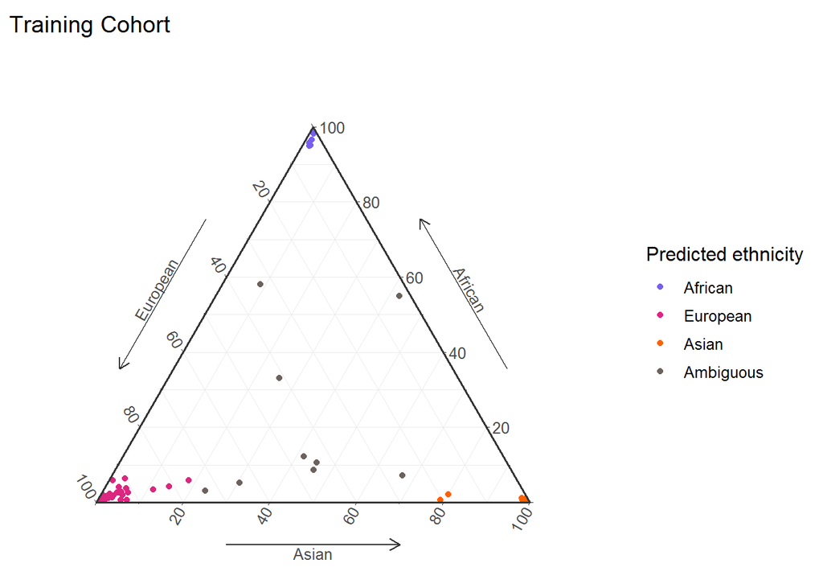

```r
trainMeta %>%
  mutate(European = Prob_Caucasian,
         African = Prob_African,
         Asian = Prob_Asian) %>%
  mutate(Predicted_ethnicity = case_when(Predicted_ethnicity == "Caucasian" ~ "European",
                                         Predicted_ethnicity == "African" ~ "African",
                                         Predicted_ethnicity == "Asian" ~ "Asian",
                                         Predicted_ethnicity == "Ambiguous" ~ "Ambiguous")) %>%
  ggtern(aes(x=European, y=African, z=Asian, color=fct_relevel(Predicted_ethnicity,
                                                               c("African", "European", "Asian",
                                                                 "Ambiguous")))) +
  geom_point() +
  scale_color_manual(values=c("#785EF0", "#DC267F", "#FE6100", "#6B625E")) +
  theme_bw() +
  theme_showarrows() +
  theme_hidetitles() +
  labs(color = "Predicted ethnicity") +
  ggtitle("Training Cohort")
```

```r
tabyl(trainMeta, Predicted_ethnicity)
```

```
##  Predicted_ethnicity  n   percent
##              African 10 0.1204819
##            Ambiguous  9 0.1084337
##                Asian 10 0.1204819
##            Caucasian 54 0.6506024
```

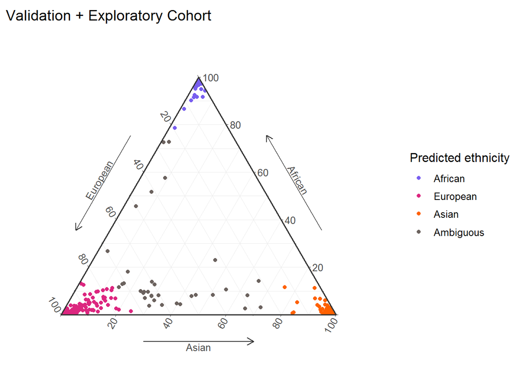

```r
ggsave(here::here("Output", "2022_Manuscript", "FigureSupp_Ancestry.png"),
       width=7, height=7,
       dpi=300)

meta %>%
  mutate(European = Prob_Caucasian,
         African = Prob_African,
         Asian = Prob_Asian) %>%
  filter(!is.na(Predicted_ethnicity_nothresh)) %>%
  mutate(Predicted_ethnicity = case_when(Highest_Prob < 0.75 ~ "Ambiguous",
    Predicted_ethnicity_nothresh == "Caucasian" ~ "European",
                                         Predicted_ethnicity_nothresh == "African" ~ "African",
                                         Predicted_ethnicity_nothresh == "Asian" ~ "Asian")) %>%
  ggtern(aes(x=European, y=African, z=Asian, color=fct_relevel(Predicted_ethnicity,
                                                               c("African", "European", "Asian",
                                                                 "Ambiguous")))) +
  geom_point() +
  scale_color_manual(values=c("#785EF0", "#DC267F", "#FE6100", "#6B625E")) +
  theme_bw() +
  theme_showarrows() +
  theme_hidetitles() +
  labs(color = "Predicted ethnicity") +
  ggtitle("Validation + Exploratory Cohort")
```

```r
tabyl(meta, Predicted_ethnicity_nothresh)
```

```
##  Predicted_ethnicity_nothresh   n    percent valid_percent
##                       African  57 0.15119363     0.1515957
##                         Asian  88 0.23342175     0.2340426
##                     Caucasian 231 0.61273210     0.6143617
##                          <NA>   1 0.00265252            NA
```

```r
ggsave(here::here("Output", "2022_Manuscript", "FigureSupp_Ancestry_ValExp.png"),
       width=7, height=7,
       dpi=300)

range(expMeta %>% filter(Class == "EOPE") %>% pull(GA_RPC))
```

```
## [1] 32.57168 32.99727
```

```r
mean(expMeta %>% filter(Class == "EOPE") %>% pull(GA_RPC))
```

```
## [1] 32.78448
```

```r
tabyl(expMeta %>% filter(Class == "EOPE"), Sex)
```

```
##     Sex n percent
##  Female 1     0.5
##    Male 1     0.5
```

```r
range(expMeta %>% filter(Class == "LatePE") %>% pull(GA_RPC))
```

```
## [1] 34.01621 40.68911
```

```r
mean(expMeta %>% filter(Class == "LatePE") %>% pull(GA_RPC))
```

```
## [1] 36.9667
```

```r
tabyl(expMeta %>% filter(Class == "LatePE"), Sex)
```

```
##     Sex  n   percent
##  Female 41 0.4767442
##    Male 45 0.5232558
```

```r
range(expMeta %>% filter(Class == "FGR") %>% pull(GA_RPC))
```

```
## [1] 28.17081 39.74962
```

```r
mean(expMeta %>% filter(Class == "FGR") %>% pull(GA_RPC))
```

```
## [1] 36.43338
```

```r
tabyl(expMeta %>% filter(Class == "FGR"), Sex)
```

```
##     Sex  n   percent
##  Female 22 0.4782609
##    Male 24 0.5217391
```

```r
range(expMeta %>% filter(Class == "Non-PE Preterm") %>% pull(GA_RPC))
```

```
## [1] 28.11963 36.97615
```

```r
mean(expMeta %>% filter(Class == "Non-PE Preterm") %>% pull(GA_RPC))
```

```
## [1] 33.10649
```

```r
tabyl(expMeta %>% filter(Class == "Non-PE Preterm"), Sex)
```

```
##     Sex n   percent
##  Female 1 0.3333333
##    Male 2 0.6666667
```

```r
range(expMeta %>% filter(Class == "Non-PE Term") %>% filter(!is.na(GA_RPC)) %>% pull(GA_RPC))
```

```
## [1] 37.00669 41.91848
```

```r
mean(expMeta %>% filter(Class == "Non-PE Term") %>% filter(!is.na(GA_RPC)) %>% pull(GA_RPC))
```

```
## [1] 38.6245
```

```r
tabyl(expMeta %>% filter(Class == "Non-PE Term"), Sex)
```

```
##     Sex  n   percent
##  Female 89 0.4917127
##    Male 92 0.5082873
```

```r
range(expMeta %>% filter(Class == "CPM16") %>% pull(GA))
```

```
## [1] 25 39
```

```r
mean(expMeta %>% filter(Class == "CPM16") %>% pull(GA))
```

```
## [1] 34.1
```

# Supplementary q - get average beta values of EOPE & nPTB samples at the 45 predictive CpGs, by dataset and ancestry

## Training

```r
library(Metrics)
tabyl(trainMeta, Class)
```

```
##           Class  n   percent
##            EOPE 42 0.5060241
##  Non-PE Preterm 41 0.4939759
```

```r
tabyl(trainMeta, Class, Predicted_ethnicity_nothresh)
```

```
##           Class African Asian Caucasian
##            EOPE       7     7        28
##  Non-PE Preterm       5     6        30
```

```r
# TRAINING
mean(long_trainPredictors %>% filter(Class == "EOPE") %>% pull(beta))
```

```
## [1] 0.4694937
```

```r
mean(long_trainPredictors %>% filter(Class == "Non-PE Preterm") %>% pull(beta))
```

```
## [1] 0.6068958
```

```r
round(abs(0.4694937-0.6068958),2)
```

```
## [1] 0.14
```

```r
t.test(long_trainPredictors %>% filter(Class == "EOPE") %>% pull(beta),
       long_trainPredictors %>% filter(Class == "Non-PE Preterm") %>% pull(beta)) # yes!
```

```
##
##  Welch Two Sample t-test
##
## data:  long_trainPredictors %>% filter(Class == "EOPE") %>% pull(beta) and long_trainPredictors %>% filter(Class == "Non-PE Preterm") %>% pull(beta)
## t = -23.443, df = 3717.8, p-value < 2.2e-16
## alternative hypothesis: true difference in means is not equal to 0
## 95 percent confidence interval:
##  -0.1488934 -0.1259107
## sample estimates:
## mean of x mean of y
## 0.4694937 0.6068958
```

```r
# by ancestry
mean(long_trainPredictors %>%
       filter(Class == "EOPE" & Predicted_ethnicity_nothresh == "Asian") %>%
       pull(beta))
```

```
## [1] 0.4909163
```

```r
mean(long_trainPredictors %>%
       filter(Class == "Non-PE Preterm" & Predicted_ethnicity_nothresh == "Asian") %>%
       pull(beta))
```

```
## [1] 0.6172085
```

```r
round(abs(0.4909163-0.6172085), 2) # 0.13
```

```
## [1] 0.13
```

```r
t.test(long_trainPredictors %>% filter(Class == "EOPE" & Predicted_ethnicity_nothresh == "Asian") %>% pull(beta),
       long_trainPredictors %>% filter(Class == "Non-PE Preterm" & Predicted_ethnicity_nothresh == "Asian") %>% pull(beta)) # yes!
```

```
##
##  Welch Two Sample t-test
##
## data:  long_trainPredictors %>% filter(Class == "EOPE" & Predicted_ethnicity_nothresh == "Asian") %>% pull(beta) and long_trainPredictors %>% filter(Class == "Non-PE Preterm" & Predicted_ethnicity_nothresh == "Asian") %>% pull(beta)
## t = -8.9045, df = 564.27, p-value < 2.2e-16
## alternative hypothesis: true difference in means is not equal to 0
## 95 percent confidence interval:
##  -0.15415017 -0.09843425
## sample estimates:
## mean of x mean of y
## 0.4909163 0.6172085
```

```r
mean(long_trainPredictors %>%
       filter(Class == "EOPE" & Predicted_ethnicity_nothresh == "Caucasian") %>%
       pull(beta))
```

```
## [1] 0.4616887
```

```r
mean(long_trainPredictors %>%
       filter(Class == "Non-PE Preterm" & Predicted_ethnicity_nothresh == "Caucasian") %>%
       pull(beta))
```

```
## [1] 0.6033051
```

```r
round(abs(0.4616887-0.6033051),2) # 0.14
```

```
## [1] 0.14
```

```r
t.test(long_trainPredictors %>% filter(Class == "EOPE" & Predicted_ethnicity_nothresh == "Caucasian") %>% pull(beta),
       long_trainPredictors %>% filter(Class == "Non-PE Preterm" & Predicted_ethnicity_nothresh == "Caucasian") %>% pull(beta)) # yes!
```

```
##
##  Welch Two Sample t-test
##
## data:  long_trainPredictors %>% filter(Class == "EOPE" & Predicted_ethnicity_nothresh == "Caucasian") %>% pull(beta) and long_trainPredictors %>% filter(Class == "Non-PE Preterm" & Predicted_ethnicity_nothresh == "Caucasian") %>% pull(beta)
## t = -20.186, df = 2608, p-value < 2.2e-16
## alternative hypothesis: true difference in means is not equal to 0
## 95 percent confidence interval:
##  -0.1553728 -0.1278600
## sample estimates:
## mean of x mean of y
## 0.4616887 0.6033051
```

```r
mean(long_trainPredictors %>%
       filter(Class == "EOPE" & Predicted_ethnicity_nothresh == "African") %>%
       pull(beta))
```

```
## [1] 0.4792914
```

```r
mean(long_trainPredictors %>%
       filter(Class == "Non-PE Preterm" & Predicted_ethnicity_nothresh == "African") %>%
       pull(beta))
```

```
## [1] 0.6160649
```

```r
round(abs(0.4792914-0.6160649), 2) # 0.14
```

```
## [1] 0.14
```

```r
t.test(long_trainPredictors %>% filter(Class == "EOPE" & Predicted_ethnicity_nothresh == "African") %>% pull(beta),
       long_trainPredictors %>% filter(Class == "Non-PE Preterm" & Predicted_ethnicity_nothresh == "African") %>% pull(beta)) # yes!
```

```
##
##  Welch Two Sample t-test
##
## data:  long_trainPredictors %>% filter(Class == "EOPE" & Predicted_ethnicity_nothresh == "African") %>% pull(beta) and long_trainPredictors %>% filter(Class == "Non-PE Preterm" & Predicted_ethnicity_nothresh == "African") %>% pull(beta)
## t = -8.575, df = 497.38, p-value < 2.2e-16
## alternative hypothesis: true difference in means is not equal to 0
## 95 percent confidence interval:
##  -0.1681117 -0.1054354
## sample estimates:
## mean of x mean of y
## 0.4792914 0.6160649
```

```r
# by dataset
tabyl(trainMeta, GEO_Dataset, Class)
```

```
##  GEO_Dataset EOPE Non-PE Preterm
##    GSE100197   22             28
##    GSE103253   11              8
##     GSE57767    5              3
##     GSE73375    4              2
```

```r
mean(long_trainPredictors %>%
       filter(Class == "EOPE" & GEO_Dataset == "GSE100197") %>%
       pull(beta))
```

```
## [1] 0.4779409
```

```r
mean(long_trainPredictors %>%
       filter(Class == "Non-PE Preterm" & GEO_Dataset == "GSE100197") %>%
       pull(beta))
```

```
## [1] 0.6171722
```

```r
abs(0.4779409-0.6171722) # 0.14
```

```
## [1] 0.1392313
```

```r
t.test(long_trainPredictors %>% filter(Class == "EOPE" & GEO_Dataset == "GSE100197") %>% pull(beta),
       long_trainPredictors %>% filter(Class == "Non-PE Preterm" & GEO_Dataset == "GSE100197") %>% pull(beta)) # yes!
```

```
##
##  Welch Two Sample t-test
##
## data:  long_trainPredictors %>% filter(Class == "EOPE" & GEO_Dataset == "GSE100197") %>% pull(beta) and long_trainPredictors %>% filter(Class == "Non-PE Preterm" & GEO_Dataset == "GSE100197") %>% pull(beta)
## t = -18.543, df = 2162.5, p-value < 2.2e-16
## alternative hypothesis: true difference in means is not equal to 0
## 95 percent confidence interval:
##  -0.1539563 -0.1245062
## sample estimates:
## mean of x mean of y
## 0.4779409 0.6171722
```

```r
mean(long_trainPredictors %>%
       filter(Class == "EOPE" & GEO_Dataset == "GSE103253") %>%
       pull(beta))
```

```
## [1] 0.4658995
```

```r
mean(long_trainPredictors %>%
       filter(Class == "Non-PE Preterm" & GEO_Dataset == "GSE103253") %>%
       pull(beta))
```

```
## [1] 0.610967
```

```r
abs(0.4658995-0.610967) # 0.14
```

```
## [1] 0.1450675
```

```r
t.test(long_trainPredictors %>% filter(Class == "EOPE" & GEO_Dataset == "GSE103253") %>% pull(beta),
       long_trainPredictors %>% filter(Class == "Non-PE Preterm" & GEO_Dataset == "GSE103253") %>% pull(beta)) # yes!
```

```
##
##  Welch Two Sample t-test
##
## data:  long_trainPredictors %>% filter(Class == "EOPE" & GEO_Dataset == "GSE103253") %>% pull(beta) and long_trainPredictors %>% filter(Class == "Non-PE Preterm" & GEO_Dataset == "GSE103253") %>% pull(beta)
## t = -11.967, df = 737.57, p-value < 2.2e-16
## alternative hypothesis: true difference in means is not equal to 0
## 95 percent confidence interval:
##  -0.1688663 -0.1212689
## sample estimates:
## mean of x mean of y
## 0.4658995 0.6109670
```

```r
mean(long_trainPredictors %>%
       filter(Class == "EOPE" & GEO_Dataset == "GSE57767") %>%
       pull(beta))
```

```
## [1] 0.5143778
```

```r
mean(long_trainPredictors %>%
       filter(Class == "Non-PE Preterm" & GEO_Dataset == "GSE57767") %>%
       pull(beta))
```

```
## [1] 0.5862726
```

```r
abs(0.5143778-0.5862726) # 0.07, way lower
```

```
## [1] 0.0718948
```

```r
t.test(long_trainPredictors %>% filter(Class == "EOPE" & GEO_Dataset == "GSE57767") %>% pull(beta),
       long_trainPredictors %>% filter(Class == "Non-PE Preterm" & GEO_Dataset == "GSE57767") %>% pull(beta)) # yes!
```

```
##
##  Welch Two Sample t-test
##
## data:  long_trainPredictors %>% filter(Class == "EOPE" & GEO_Dataset == "GSE57767") %>% pull(beta) and long_trainPredictors %>% filter(Class == "Non-PE Preterm" & GEO_Dataset == "GSE57767") %>% pull(beta)
## t = -3.5748, df = 299.88, p-value = 0.0004084
## alternative hypothesis: true difference in means is not equal to 0
## 95 percent confidence interval:
##  -0.1114725 -0.0323170
## sample estimates:
## mean of x mean of y
## 0.5143778 0.5862726
```

```r
mean(long_trainPredictors %>%
       filter(Class == "EOPE" & GEO_Dataset == "GSE73375") %>%
       pull(beta))
```

```
## [1] 0.3768132
```

```r
mean(long_trainPredictors %>%
       filter(Class == "Non-PE Preterm" & GEO_Dataset == "GSE73375") %>%
       pull(beta))
```

```
## [1] 0.4776764
```

```r
abs(0.3768132-0.4776764) # 0.10, similar!
```

```
## [1] 0.1008632
```

```r
t.test(long_trainPredictors %>% filter(Class == "EOPE" & GEO_Dataset == "GSE73375") %>% pull(beta),
       long_trainPredictors %>% filter(Class == "Non-PE Preterm" & GEO_Dataset == "GSE73375") %>% pull(beta)) # yes!
```

```
##
##  Welch Two Sample t-test
##
## data:  long_trainPredictors %>% filter(Class == "EOPE" & GEO_Dataset == "GSE73375") %>% pull(beta) and long_trainPredictors %>% filter(Class == "Non-PE Preterm" & GEO_Dataset == "GSE73375") %>% pull(beta)
## t = -4.7996, df = 162.87, p-value = 3.574e-06
## alternative hypothesis: true difference in means is not equal to 0
## 95 percent confidence interval:
##  -0.14235977 -0.05936663
## sample estimates:
## mean of x mean of y
## 0.3768132 0.4776764
```

## Validation

```r
head(long_predictors)
```

```
##          cpg  Sample_ID      beta Subject_ID GEO_Dataset    Sex   Condition
## 1 cg10246581 GSM1388230 0.6527898       <NA>    GSE57767 Female Non-PE Term
## 2 cg09911083 GSM1388230 0.6301145       <NA>    GSE57767 Female Non-PE Term
## 3 cg18584265 GSM1388230 0.6591328       <NA>    GSE57767 Female Non-PE Term
## 4 cg12632411 GSM1388230 0.5669558       <NA>    GSE57767 Female Non-PE Term
## 5 cg07913153 GSM1388230 0.3855307       <NA>    GSE57767 Female Non-PE Term
## 6 cg10994126 GSM1388230 0.6079692       <NA>    GSE57767 Female Non-PE Term
##      IUGR Preterm Term PE GA   GA_RPC Ethnicity Maternal_Age Chip  Row Column
## 1 Unknown      No  Yes No NA 38.37877      <NA>           NA   NA <NA>   <NA>
## 2 Unknown      No  Yes No NA 38.37877      <NA>           NA   NA <NA>   <NA>
## 3 Unknown      No  Yes No NA 38.37877      <NA>           NA   NA <NA>   <NA>
## 4 Unknown      No  Yes No NA 38.37877      <NA>           NA   NA <NA>   <NA>
## 5 Unknown      No  Yes No NA 38.37877      <NA>           NA   NA <NA>   <NA>
## 6 Unknown      No  Yes No NA 38.37877      <NA>           NA   NA <NA>   <NA>
##   Predicted_ethnicity_nothresh Predicted_ethnicity Prob_African  Prob_Asian
```

[output cut: 34 more lines]

```r
tabyl(valMeta, Class, Predicted_ethnicity_nothresh)
```

```
##           Class African Asian Caucasian
##            EOPE       5    26         7
##  Non-PE Preterm       0     2         9
```

```r
tabyl(valMeta, Class, Predicted_ethnicity_nothresh, GEO_Dataset)
```

```
## $GSE125605
##           Class African Asian Caucasian
##            EOPE       0    22         0
##  Non-PE Preterm       0     1         0
##
## $GSE203396
##           Class African Asian Caucasian
##            EOPE       0     0         0
##  Non-PE Preterm       0     0         5
##
## $GSE98224
##           Class African Asian Caucasian
##            EOPE       5     4         7
##  Non-PE Preterm       0     1         4
```

```r
mean(long_predictors %>% filter(Group == "Validation" & Class == "EOPE") %>% pull(beta))
```

```
## [1] 0.4875962
```

```r
mean(long_predictors %>% filter(Group == "Validation" & Class == "Non-PE Preterm") %>% pull(beta))
```

```
## [1] 0.5455664
```

```r
round(abs(0.4875962-0.5455664), 2) # 0.06
```

```
## [1] 0.06
```

```r
t.test(long_predictors %>% filter(Group == "Validation" & Class == "EOPE") %>% pull(beta),
       long_predictors %>% filter(Group == "Validation" & Class == "Non-PE Preterm") %>% pull(beta)) # yes!
```

```
##
##  Welch Two Sample t-test
##
## data:  long_predictors %>% filter(Group == "Validation" & Class == "EOPE") %>% pull(beta) and long_predictors %>% filter(Group == "Validation" & Class == "Non-PE Preterm") %>% pull(beta)
## t = -6.2793, df = 756.7, p-value = 5.731e-10
## alternative hypothesis: true difference in means is not equal to 0
## 95 percent confidence interval:
##  -0.07609360 -0.03984678
## sample estimates:
## mean of x mean of y
## 0.4875962 0.5455664
```

```r
# by ancestry
mean(long_predictors %>% filter(Group == "Validation" & Class == "EOPE" & Predicted_ethnicity_nothresh == 'Asian') %>% pull(beta))
```

```
## [1] 0.5125792
```

```r
mean(long_predictors %>% filter(Group == "Validation" & Class == "Non-PE Preterm" & Predicted_ethnicity_nothresh == 'Asian') %>% pull(beta))
```

```
## [1] 0.5489307
```

```r
round(abs(0.5125792-0.5489307), 2) # 0.03
```

```
## [1] 0.04
```

```r
t.test(long_predictors %>% filter(Group == "Validation" & Class == "EOPE" & Predicted_ethnicity_nothresh == 'Asian') %>% pull(beta),
       long_predictors %>% filter(Group == "Validation" & Class == "Non-PE Preterm" & Predicted_ethnicity_nothresh == 'Asian') %>% pull(beta)) # yes!
```

```
##
##  Welch Two Sample t-test
##
## data:  long_predictors %>% filter(Group == "Validation" & Class == "EOPE" & Predicted_ethnicity_nothresh == "Asian") %>% pull(beta) and long_predictors %>% filter(Group == "Validation" & Class == "Non-PE Preterm" & Predicted_ethnicity_nothresh == "Asian") %>% pull(beta)
## t = -1.8697, df = 102.45, p-value = 0.06439
## alternative hypothesis: true difference in means is not equal to 0
## 95 percent confidence interval:
##  -0.074914169  0.002211328
## sample estimates:
## mean of x mean of y
## 0.5125792 0.5489307
```

```r
mean(long_predictors %>% filter(Group == "Validation" & Class == "EOPE" & Predicted_ethnicity_nothresh == 'Caucasian') %>% pull(beta))
```

```
## [1] 0.4268139
```

```r
mean(long_predictors %>% filter(Group == "Validation" & Class == "Non-PE Preterm" & Predicted_ethnicity_nothresh == 'Caucasian') %>% pull(beta))
```

```
## [1] 0.5448187
```

```r
round(abs(0.4268139-0.5448187),2) # 0.12
```

```
## [1] 0.12
```

```r
t.test(long_predictors %>% filter(Group == "Validation" & Class == "EOPE" & Predicted_ethnicity_nothresh == 'Caucasian') %>% pull(beta),
       long_predictors %>% filter(Group == "Validation" & Class == "Non-PE Preterm" & Predicted_ethnicity_nothresh == 'Caucasian') %>% pull(beta)) # yes!
```

```
##
##  Welch Two Sample t-test
##
## data:  long_predictors %>% filter(Group == "Validation" & Class == "EOPE" & Predicted_ethnicity_nothresh == "Caucasian") %>% pull(beta) and long_predictors %>% filter(Group == "Validation" & Class == "Non-PE Preterm" & Predicted_ethnicity_nothresh == "Caucasian") %>% pull(beta)
## t = -9.4683, df = 717.16, p-value < 2.2e-16
## alternative hypothesis: true difference in means is not equal to 0
## 95 percent confidence interval:
##  -0.14247345 -0.09353633
## sample estimates:
## mean of x mean of y
## 0.4268139 0.5448187
```

```r
# by dataset
mean(long_predictors %>% filter(Group == "Validation" & Class == "EOPE" & GEO_Dataset == "GSE125605") %>% pull(beta))
```

```
## [1] 0.5339444
```

```r
mean(long_predictors %>% filter(Group == "Validation" & Class == "Non-PE Preterm" & GEO_Dataset == 'GSE125605') %>% pull(beta))
```

```
## [1] 0.5400977
```

```r
abs(0.5339444-0.5400977) # 0.006
```

```
## [1] 0.0061533
```

```r
# for comparison, although i cannot run a t-test, the mean B value of the 4 asian samples in GSE98224
mean(long_predictors %>% filter(Group == "Validation" & Class == "EOPE" & GEO_Dataset == "GSE98224" & Predicted_ethnicity_nothresh == "Asian") %>% pull(beta)) # 0.395
```

```
## [1] 0.3950707
```

```r
t.test(long_predictors %>% filter(Group == "Validation" & Class == "EOPE" & GEO_Dataset == "GSE125605") %>% pull(beta),
       long_predictors %>% filter(Group == "Validation" & Class == "Non-PE Preterm" & GEO_Dataset == "GSE125605") %>% pull(beta)) # not significant, 0.82
```

```
##
##  Welch Two Sample t-test
##
## data:  long_predictors %>% filter(Group == "Validation" & Class == "EOPE" & GEO_Dataset == "GSE125605") %>% pull(beta) and long_predictors %>% filter(Group == "Validation" & Class == "Non-PE Preterm" & GEO_Dataset == "GSE125605") %>% pull(beta)
## t = -0.22429, df = 47.674, p-value = 0.8235
## alternative hypothesis: true difference in means is not equal to 0
## 95 percent confidence interval:
##  -0.06132281  0.04901630
## sample estimates:
## mean of x mean of y
## 0.5339444 0.5400977
```

```r
mean(long_predictors %>% filter(Group == "Validation" & Class == "EOPE" & GEO_Dataset == "GSE98224") %>% pull(beta))
```

```
## [1] 0.4238674
```

```r
mean(long_predictors %>% filter(Group == "Validation" & Class == "Non-PE Preterm" & GEO_Dataset == 'GSE98224') %>% pull(beta))
```

```
## [1] 0.5617401
```

```r
abs(0.4238674-0.5617401) # 0.14
```

```
## [1] 0.1378727
```

```r
t.test(long_predictors %>% filter(Group == "Validation" & Class == "EOPE" & GEO_Dataset == "GSE98224") %>% pull(beta),
       long_predictors %>% filter(Group == "Validation" & Class == "Non-PE Preterm" & GEO_Dataset == "GSE98224") %>% pull(beta)) # significant
```

```
##
##  Welch Two Sample t-test
##
## data:  long_predictors %>% filter(Group == "Validation" & Class == "EOPE" & GEO_Dataset == "GSE98224") %>% pull(beta) and long_predictors %>% filter(Group == "Validation" & Class == "Non-PE Preterm" & GEO_Dataset == "GSE98224") %>% pull(beta)
## t = -10.603, df = 326.6, p-value < 2.2e-16
## alternative hypothesis: true difference in means is not equal to 0
## 95 percent confidence interval:
##  -0.1634524 -0.1122930
## sample estimates:
## mean of x mean of y
## 0.4238674 0.5617401
```

```r
mean(long_predictors %>% filter(Group == "Validation" & Class == "Non-PE Preterm" & GEO_Dataset == "GSE203396") %>% pull(beta))
```

```
## [1] 0.5304864
```

What is the average beta of term samples in GSE125605?

```r
mean(long_predictors %>% filter(GEO_Dataset == "GSE125605" & Class == "Non-PE Term") %>% pull(beta)) # 0.62
```

```
## [1] 0.6146779
```

## Cell composition of GSE98224 and GSE125605 by sample

[output not shown]

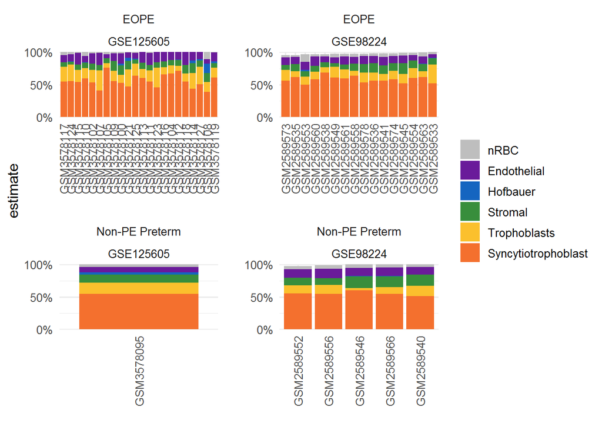

```r
meta %>%
  dplyr::filter(GEO_Dataset %in% c("GSE98224", "GSE125605")) %>%
  dplyr::filter(Class %in% c('EOPE', 'Non-PE Preterm')) %>%
  dplyr::select(c(Sample_ID, Trophoblasts, Stromal, Hofbauer,
                  Endothelial, nRBC, Syncytiotrophoblast,
                  GEO_Dataset, Class)) %>%
  pivot_longer(cols = -c(Sample_ID, GEO_Dataset, Class),
               names_to = "component",
               values_to = "estimate") %>%
  mutate(component = factor(component, levels = c("nRBC", "Endothelial", "Hofbauer",
                                                  "Stromal", "Trophoblasts",
                                                  "Syncytiotrophoblast"))) %>%
  arrange(Sample_ID, component) %>%
    # plot
    ggplot(aes(x = reorder(Sample_ID, estimate), y = estimate, fill = component)) +
    geom_bar(stat = "identity") +
    scale_fill_manual(values = plColors) +
    scale_y_continuous(
        limits = c(-0.1, 1.1), breaks = c(0, 0.5, 1),
        labels = scales::percent,
        expand = c(0, 0)) +
    facet_wrap(Class~GEO_Dataset, scales="free", drop=TRUE) +
    theme_minimal() +
    theme(axis.text.x = element_text(angle = 90, vjust = 0.5),
          panel.spacing = unit(1.5,'lines')) +
    coord_cartesian(ylim = c(0, 1)) +
    labs(x = "", fill = "")
```

```r
ggsave(here::here("Output", "2022_Manuscript", "FigureSupp_CellComp_GSE98224_GSE100197.png"),
       width=10, height=10,
       dpi=200)
```

```r
tabyl(meta %>% filter(GEO_Dataset == 'GSE98224'), Class, Predicted_ethnicity_nothresh)
```

```
##           Class African Asian Caucasian
##            EOPE       5     4         7
##             FGR       1     2         1
##          LatePE       1     3        10
##  Non-PE Preterm       0     1         4
##     Non-PE Term       0     4         5
```